# JRF Nat Rep - Data cleaning

Authors

Jolyon Miles-Wilson

Celestin Okoroji

Published

May 1, 2025

```r
rm(list = ls())
# Load libraries
library(gridExtra)
library(skimr)
library(haven)
library(tidyverse)
library(wesanderson)
library(Hmisc)
colours <- wes_palette("GrandBudapest2",4,"discrete")
```

# Resolving the two datasets received from Opinium

We received two datasets on two separate occasions from Opinium. The second contains occupation and sector data that the first didn’t include. The first thing we need to do is understand the differences between these two datasets to determine whether we can simply choose one dataset, and which one this should be.

**TLDR**

The second dataset is an updated version of the first. Although there are some variables that are present in one dataset but not in the other, investigating these differences indicates that there is no problem with simply using the second dataset instead of the first. Read on for details on the steps taken to determine this.

```r
# Read the first data we received from opinium
data <- read_sav("../Data/UK23626 Workers sample data with nat rep and graduates weight.sav")
# View(data)

# read the second data we received from opinium. This includes more job/sector information
data_2 <- read_sav("../Data/JRF Outsourced Workers - Occupations and Sectors.sav")
# skim(data_2)
```

```r
# Investigate the differences between the two datasets
check_columns <- function(data1, data2){
  variables_absent <- c()
  total <- 0
  cols1 <- colnames(data1)
  cols2 <- colnames(data2)

  # For each item in cols1, check whether it exists in cols2
  for(x in seq_along(cols1)){
    this_var = cols1[x]
    present = this_var %in% cols2
    total = total + present
    missing = length(cols1) - total
    # Create vector of all missing vars
    if(!present){
      variables_absent = append(variables_absent, this_var)
    }
  }
  cat(paste0(missing, " columns in ", deparse(substitute(data1)), " missing from ", deparse(substitute(data2)),":"))
  cat(paste0("\n",variables_absent))
  cat("\n")
  return(variables_absent)
}

vars_absent1 <- check_columns(data, data_2)
```

```
11 columns in data missing from data_2:
StartTime
Agegender_recode_useforquota
Q3v1_1
Q3v1_2
Q3v1_3
Q3v1_4
Q3v1_5
Q3v2_1
Q3v2_2
Q3v4a
Q3v4b
```

```r
vars_absent2 <- check_columns(data_2, data)
```

```
9 columns in data_2 missing from data:
ed_bands
unit_code
UnitOccupation
smg_code
MajorsubgroupOccupation
major_code
Majorgroupcode
SectorCode
SectorName
```

Looking at the variables in data that are missing from data_2, all but two are completely missing (complete_rate = 0), and the remaining two (startTime and agegender_recode_useforquota) are not needed. This exercise indicates that we can just switch to using data_2 instead of data.

```r
vars_absent1_subset <- dplyr::select(data, dplyr::all_of(vars_absent1))

skim(vars_absent1_subset)
```

Data summary

| Name | vars_absent1_subset |
| --- | --- |
| Number of rows | 10155 |
| Number of columns | 11 |
| _______________________ |  |
| Column type frequency: |  |
| numeric | 11 |
| ________________________ |  |
| Group variables | None |

**Variable type: numeric**

| skim_variable | n_missing | complete_rate | mean | sd | p0 | p25 | p50 | p75 | p100 | hist |
| --- | --- | --- | --- | --- | --- | --- | --- | --- | --- | --- |
| StartTime | 0 | 1 | 152128.49 | 49331.93 | 4 | 125642 | 160423 | 185037.5 | 235940 | ▁▂▅▇▅ |
| Agegender_recode_useforquota | 0 | 1 | 5.54 | 2.72 | 1 | 3 | 6 | 8.0 | 11 | ▇▅▅▇▁ |
| Q3v1_1 | 10155 | 0 | NaN | NA | NA | NA | NA | NA | NA |  |
| Q3v1_2 | 10155 | 0 | NaN | NA | NA | NA | NA | NA | NA |  |
| Q3v1_3 | 10155 | 0 | NaN | NA | NA | NA | NA | NA | NA |  |
| Q3v1_4 | 10155 | 0 | NaN | NA | NA | NA | NA | NA | NA |  |
| Q3v1_5 | 10155 | 0 | NaN | NA | NA | NA | NA | NA | NA |  |
| Q3v2_1 | 10155 | 0 | NaN | NA | NA | NA | NA | NA | NA |  |
| Q3v2_2 | 10155 | 0 | NaN | NA | NA | NA | NA | NA | NA |  |
| Q3v4a | 10155 | 0 | NaN | NA | NA | NA | NA | NA | NA |  |
| Q3v4b | 10155 | 0 | NaN | NA | NA | NA | NA | NA | NA |  |

Visual inspection of a skim of each dataset indicates they are the same.

```r
skim(data)
```

Data summary

| Name | data |
| --- | --- |
| Number of rows | 10155 |
| Number of columns | 88 |
| _______________________ |  |
| Column type frequency: |  |
| character | 7 |
| numeric | 81 |
| ________________________ |  |
| Group variables | None |

**Variable type: character**

| skim_variable | n_missing | complete_rate | min | max | empty | n_unique | whitespace |
| --- | --- | --- | --- | --- | --- | --- | --- |
| MIProRspId | 0 | 1 | 36 | 36 | 0 | 10155 | 0 |
| E6_5_other | 0 | 1 | 0 | 102 | 10142 | 14 | 0 |
| E8A | 0 | 1 | 2 | 124 | 0 | 4946 | 0 |
| E8B | 0 | 1 | 2 | 274 | 0 | 6559 | 0 |
| E9A | 0 | 1 | 2 | 185 | 0 | 4369 | 0 |
| E10B_9_other | 0 | 1 | 0 | 75 | 9992 | 132 | 0 |
| Q2_3_other | 0 | 1 | 0 | 93 | 9988 | 140 | 0 |

**Variable type: numeric**

| skim_variable | n_missing | complete_rate | mean | sd | p0 | p25 | p50 | p75 | p100 | hist |
| --- | --- | --- | --- | --- | --- | --- | --- | --- | --- | --- |
| StartTime | 0 | 1.00 | 152128.49 | 49331.93 | 4.00 | 125642.00 | 160423.00 | 185037.50 | 235940.00 | ▁▂▅▇▅ |
| D1_Gender_C | 0 | 1.00 | 1.53 | 0.54 | 1.00 | 1.00 | 2.00 | 2.00 | 4.00 | ▇▇▁▁▁ |
| D2_Age | 0 | 1.00 | 42.15 | 13.03 | 16.00 | 32.00 | 42.00 | 53.00 | 81.00 | ▅▇▇▅▁ |
| Agegender_recode_useforquota | 0 | 1.00 | 5.54 | 2.72 | 1.00 | 3.00 | 6.00 | 8.00 | 11.00 | ▇▅▅▇▁ |
| D4_Region_C | 0 | 1.00 | 7.25 | 3.39 | 1.00 | 4.00 | 7.00 | 10.00 | 12.00 | ▃▅▃▃▇ |
| D3_employment | 0 | 1.00 | 1.24 | 0.45 | 1.00 | 1.00 | 1.00 | 1.00 | 3.00 | ▇▁▂▁▁ |
| E2 | 0 | 1.00 | 1.00 | 0.00 | 1.00 | 1.00 | 1.00 | 1.00 | 1.00 | ▁▁▇▁▁ |
| SCD_Opt_In_1 | 0 | 1.00 | 1.03 | 0.18 | 1.00 | 1.00 | 1.00 | 1.00 | 2.00 | ▇▁▁▁▁ |
| SCD_Opt_In_2 | 0 | 1.00 | 1.07 | 0.26 | 1.00 | 1.00 | 1.00 | 1.00 | 2.00 | ▇▁▁▁▁ |
| SCD_Opt_In_3 | 0 | 1.00 | 1.04 | 0.20 | 1.00 | 1.00 | 1.00 | 1.00 | 2.00 | ▇▁▁▁▁ |
| Ethnicity | 343 | 0.97 | 2.89 | 4.26 | 1.00 | 1.00 | 1.00 | 1.00 | 21.00 | ▇▁▁▁▁ |
| D6_educ1 | 0 | 1.00 | 1.47 | 0.52 | 1.00 | 1.00 | 1.00 | 2.00 | 3.00 | ▇▁▆▁▁ |
| D7_educ2_1 | 5527 | 0.46 | 0.56 | 0.50 | 0.00 | 0.00 | 1.00 | 1.00 | 1.00 | ▆▁▁▁▇ |
| D7_educ2_2 | 5527 | 0.46 | 0.26 | 0.44 | 0.00 | 0.00 | 0.00 | 1.00 | 1.00 | ▇▁▁▁▃ |
| D7_educ2_3 | 5527 | 0.46 | 0.21 | 0.41 | 0.00 | 0.00 | 0.00 | 0.00 | 1.00 | ▇▁▁▁▂ |
| D7_educ2_4 | 5527 | 0.46 | 0.06 | 0.24 | 0.00 | 0.00 | 0.00 | 0.00 | 1.00 | ▇▁▁▁▁ |
| D7_educ2_5 | 5527 | 0.46 | 0.02 | 0.15 | 0.00 | 0.00 | 0.00 | 0.00 | 1.00 | ▇▁▁▁▁ |
| D7_educ2_6 | 5527 | 0.46 | 0.02 | 0.13 | 0.00 | 0.00 | 0.00 | 0.00 | 1.00 | ▇▁▁▁▁ |
| D7_educ2_7 | 5527 | 0.46 | 0.22 | 0.41 | 0.00 | 0.00 | 0.00 | 0.00 | 1.00 | ▇▁▁▁▂ |
| D7_educ2_8 | 5527 | 0.46 | 0.15 | 0.36 | 0.00 | 0.00 | 0.00 | 0.00 | 1.00 | ▇▁▁▁▂ |
| D7_educ2_9 | 5527 | 0.46 | 0.06 | 0.24 | 0.00 | 0.00 | 0.00 | 0.00 | 1.00 | ▇▁▁▁▁ |
| D7_educ2_10 | 5527 | 0.46 | 0.07 | 0.26 | 0.00 | 0.00 | 0.00 | 0.00 | 1.00 | ▇▁▁▁▁ |
| D7_educ2_11 | 5527 | 0.46 | 0.10 | 0.30 | 0.00 | 0.00 | 0.00 | 0.00 | 1.00 | ▇▁▁▁▁ |
| D7_educ2_12 | 5527 | 0.46 | 0.05 | 0.22 | 0.00 | 0.00 | 0.00 | 0.00 | 1.00 | ▇▁▁▁▁ |
| D7_educ2_13 | 5527 | 0.46 | 0.02 | 0.15 | 0.00 | 0.00 | 0.00 | 0.00 | 1.00 | ▇▁▁▁▁ |
| TradeUnion | 737 | 0.93 | 1.71 | 0.48 | 1.00 | 1.00 | 2.00 | 2.00 | 3.00 | ▃▁▇▁▁ |
| D6_Children_1 | 0 | 1.00 | 0.02 | 0.14 | 0.00 | 0.00 | 0.00 | 0.00 | 1.00 | ▇▁▁▁▁ |
| D6_Children_2 | 0 | 1.00 | 0.13 | 0.33 | 0.00 | 0.00 | 0.00 | 0.00 | 1.00 | ▇▁▁▁▁ |
| D6_Children_3 | 0 | 1.00 | 0.10 | 0.30 | 0.00 | 0.00 | 0.00 | 0.00 | 1.00 | ▇▁▁▁▁ |
| D6_Children_4 | 0 | 1.00 | 0.13 | 0.33 | 0.00 | 0.00 | 0.00 | 0.00 | 1.00 | ▇▁▁▁▁ |

[output cut: 51 more lines]

```r
skim(data_2)
```

Data summary

| Name | data_2 |
| --- | --- |
| Number of rows | 10155 |
| Number of columns | 86 |
| _______________________ |  |
| Column type frequency: |  |
| character | 7 |
| numeric | 79 |
| ________________________ |  |
| Group variables | None |

**Variable type: character**

| skim_variable | n_missing | complete_rate | min | max | empty | n_unique | whitespace |
| --- | --- | --- | --- | --- | --- | --- | --- |
| MIProRspId | 0 | 1 | 36 | 36 | 0 | 10155 | 0 |
| E6_5_other | 0 | 1 | 0 | 102 | 10142 | 14 | 0 |
| E8A | 0 | 1 | 2 | 124 | 0 | 4946 | 0 |
| E8B | 0 | 1 | 2 | 274 | 0 | 6559 | 0 |
| E9A | 0 | 1 | 2 | 185 | 0 | 4369 | 0 |
| E10B_9_other | 0 | 1 | 0 | 75 | 9992 | 132 | 0 |
| Q2_3_other | 0 | 1 | 0 | 93 | 9988 | 140 | 0 |

**Variable type: numeric**

| skim_variable | n_missing | complete_rate | mean | sd | p0 | p25 | p50 | p75 | p100 | hist |
| --- | --- | --- | --- | --- | --- | --- | --- | --- | --- | --- |
| D1_Gender_C | 0 | 1.00 | 1.53 | 0.54 | 1.00 | 1.00 | 2.00 | 2.00 | 4.00e+00 | ▇▇▁▁▁ |
| D2_Age | 0 | 1.00 | 42.15 | 13.03 | 16.00 | 32.00 | 42.00 | 53.00 | 8.10e+01 | ▅▇▇▅▁ |
| D4_Region_C | 0 | 1.00 | 7.25 | 3.39 | 1.00 | 4.00 | 7.00 | 10.00 | 1.20e+01 | ▃▅▃▃▇ |
| D3_employment | 0 | 1.00 | 1.24 | 0.45 | 1.00 | 1.00 | 1.00 | 1.00 | 3.00e+00 | ▇▁▂▁▁ |
| E2 | 0 | 1.00 | 1.00 | 0.00 | 1.00 | 1.00 | 1.00 | 1.00 | 1.00e+00 | ▁▁▇▁▁ |
| SCD_Opt_In_1 | 0 | 1.00 | 1.03 | 0.18 | 1.00 | 1.00 | 1.00 | 1.00 | 2.00e+00 | ▇▁▁▁▁ |
| SCD_Opt_In_2 | 0 | 1.00 | 1.07 | 0.26 | 1.00 | 1.00 | 1.00 | 1.00 | 2.00e+00 | ▇▁▁▁▁ |
| SCD_Opt_In_3 | 0 | 1.00 | 1.04 | 0.20 | 1.00 | 1.00 | 1.00 | 1.00 | 2.00e+00 | ▇▁▁▁▁ |
| Ethnicity | 343 | 0.97 | 2.89 | 4.26 | 1.00 | 1.00 | 1.00 | 1.00 | 2.10e+01 | ▇▁▁▁▁ |
| D6_educ1 | 0 | 1.00 | 1.47 | 0.52 | 1.00 | 1.00 | 1.00 | 2.00 | 3.00e+00 | ▇▁▆▁▁ |
| D7_educ2_1 | 5527 | 0.46 | 0.56 | 0.50 | 0.00 | 0.00 | 1.00 | 1.00 | 1.00e+00 | ▆▁▁▁▇ |
| D7_educ2_2 | 5527 | 0.46 | 0.26 | 0.44 | 0.00 | 0.00 | 0.00 | 1.00 | 1.00e+00 | ▇▁▁▁▃ |
| D7_educ2_3 | 5527 | 0.46 | 0.21 | 0.41 | 0.00 | 0.00 | 0.00 | 0.00 | 1.00e+00 | ▇▁▁▁▂ |
| D7_educ2_4 | 5527 | 0.46 | 0.06 | 0.24 | 0.00 | 0.00 | 0.00 | 0.00 | 1.00e+00 | ▇▁▁▁▁ |
| D7_educ2_5 | 5527 | 0.46 | 0.02 | 0.15 | 0.00 | 0.00 | 0.00 | 0.00 | 1.00e+00 | ▇▁▁▁▁ |
| D7_educ2_6 | 5527 | 0.46 | 0.02 | 0.13 | 0.00 | 0.00 | 0.00 | 0.00 | 1.00e+00 | ▇▁▁▁▁ |
| D7_educ2_7 | 5527 | 0.46 | 0.22 | 0.41 | 0.00 | 0.00 | 0.00 | 0.00 | 1.00e+00 | ▇▁▁▁▂ |
| D7_educ2_8 | 5527 | 0.46 | 0.15 | 0.36 | 0.00 | 0.00 | 0.00 | 0.00 | 1.00e+00 | ▇▁▁▁▂ |
| D7_educ2_9 | 5527 | 0.46 | 0.06 | 0.24 | 0.00 | 0.00 | 0.00 | 0.00 | 1.00e+00 | ▇▁▁▁▁ |
| D7_educ2_10 | 5527 | 0.46 | 0.07 | 0.26 | 0.00 | 0.00 | 0.00 | 0.00 | 1.00e+00 | ▇▁▁▁▁ |
| D7_educ2_11 | 5527 | 0.46 | 0.10 | 0.30 | 0.00 | 0.00 | 0.00 | 0.00 | 1.00e+00 | ▇▁▁▁▁ |
| D7_educ2_12 | 5527 | 0.46 | 0.05 | 0.22 | 0.00 | 0.00 | 0.00 | 0.00 | 1.00e+00 | ▇▁▁▁▁ |
| D7_educ2_13 | 5527 | 0.46 | 0.02 | 0.15 | 0.00 | 0.00 | 0.00 | 0.00 | 1.00e+00 | ▇▁▁▁▁ |
| ed_bands | 0 | 1.00 | 2.43 | 0.68 | 1.00 | 2.00 | 3.00 | 3.00 | 3.00e+00 | ▂▁▅▁▇ |
| TradeUnion | 737 | 0.93 | 1.71 | 0.48 | 1.00 | 1.00 | 2.00 | 2.00 | 3.00e+00 | ▃▁▇▁▁ |
| D6_Children_1 | 0 | 1.00 | 0.02 | 0.14 | 0.00 | 0.00 | 0.00 | 0.00 | 1.00e+00 | ▇▁▁▁▁ |
| D6_Children_2 | 0 | 1.00 | 0.13 | 0.33 | 0.00 | 0.00 | 0.00 | 0.00 | 1.00e+00 | ▇▁▁▁▁ |
| D6_Children_3 | 0 | 1.00 | 0.10 | 0.30 | 0.00 | 0.00 | 0.00 | 0.00 | 1.00e+00 | ▇▁▁▁▁ |
| D6_Children_4 | 0 | 1.00 | 0.13 | 0.33 | 0.00 | 0.00 | 0.00 | 0.00 | 1.00e+00 | ▇▁▁▁▁ |
| D6_Children_5 | 0 | 1.00 | 0.10 | 0.30 | 0.00 | 0.00 | 0.00 | 0.00 | 1.00e+00 | ▇▁▁▁▁ |
| D6_Children_6 | 0 | 1.00 | 0.07 | 0.26 | 0.00 | 0.00 | 0.00 | 0.00 | 1.00e+00 | ▇▁▁▁▁ |
| D6_Children_7 | 0 | 1.00 | 0.06 | 0.24 | 0.00 | 0.00 | 0.00 | 0.00 | 1.00e+00 | ▇▁▁▁▁ |
| D6_Children_8 | 0 | 1.00 | 0.26 | 0.44 | 0.00 | 0.00 | 0.00 | 1.00 | 1.00e+00 | ▇▁▁▁▃ |
| D6_Children_9 | 0 | 1.00 | 0.39 | 0.49 | 0.00 | 0.00 | 0.00 | 1.00 | 1.00e+00 | ▇▁▁▁▅ |
| E1 | 0 | 1.00 | 1.88 | 0.33 | 1.00 | 2.00 | 2.00 | 2.00 | 2.00e+00 | ▁▁▁▁▇ |
| E3 | 0 | 1.00 | 1.07 | 0.44 | 1.00 | 1.00 | 1.00 | 1.00 | 5.00e+00 | ▇▁▁▁▁ |
| E5 | 0 | 1.00 | 1.11 | 0.39 | 1.00 | 1.00 | 1.00 | 1.00 | 3.00e+00 | ▇▁▁▁▁ |
| E6_1 | 9658 | 0.05 | 0.31 | 0.46 | 0.00 | 0.00 | 0.00 | 1.00 | 1.00e+00 | ▇▁▁▁▃ |
| E6_2 | 9658 | 0.05 | 0.60 | 0.49 | 0.00 | 0.00 | 1.00 | 1.00 | 1.00e+00 | ▆▁▁▁▇ |
| E6_3 | 9658 | 0.05 | 0.11 | 0.31 | 0.00 | 0.00 | 0.00 | 0.00 | 1.00e+00 | ▇▁▁▁▁ |
| E6_4 | 9658 | 0.05 | 0.05 | 0.21 | 0.00 | 0.00 | 0.00 | 0.00 | 1.00e+00 | ▇▁▁▁▁ |
| E6_5 | 9658 | 0.05 | 0.03 | 0.16 | 0.00 | 0.00 | 0.00 | 0.00 | 1.00e+00 | ▇▁▁▁▁ |
| E7A | 1 | 1.00 | 6.16 | 2.70 | 1.00 | 5.00 | 6.00 | 9.00 | 9.00e+00 | ▃▂▂▆▇ |
| E7B | 0 | 1.00 | 1.61 | 0.49 | 1.00 | 1.00 | 2.00 | 2.00 | 2.00e+00 | ▅▁▁▁▇ |
| E9B | 0 | 1.00 | 12.67 | 5.62 | 1.00 | 8.00 | 14.00 | 17.00 | 2.20e+01 | ▂▅▃▇▃ |
| E10A | 0 | 1.00 | 1.33 | 0.47 | 1.00 | 1.00 | 1.00 | 2.00 | 2.00e+00 | ▇▁▁▁▃ |
| E10B | 6827 | 0.33 | 4.55 | 2.03 | 1.00 | 3.00 | 4.00 | 6.00 | 9.00e+00 | ▂▇▂▆▁ |
| Q1_1 | 0 | 1.00 | 1.84 | 0.37 | 1.00 | 2.00 | 2.00 | 2.00 | 2.00e+00 | ▂▁▁▁▇ |
| Q1_2 | 0 | 1.00 | 1.81 | 0.39 | 1.00 | 2.00 | 2.00 | 2.00 | 2.00e+00 | ▂▁▁▁▇ |
| Q1_3 | 0 | 1.00 | 1.67 | 0.47 | 1.00 | 1.00 | 2.00 | 2.00 | 2.00e+00 | ▃▁▁▁▇ |
| Q1_4 | 0 | 1.00 | 1.79 | 0.41 | 1.00 | 2.00 | 2.00 | 2.00 | 2.00e+00 | ▂▁▁▁▇ |
| Q1_5 | 0 | 1.00 | 1.80 | 0.40 | 1.00 | 2.00 | 2.00 | 2.00 | 2.00e+00 | ▂▁▁▁▇ |
| Q1_6 | 0 | 1.00 | 1.71 | 0.46 | 1.00 | 1.00 | 2.00 | 2.00 | 2.00e+00 | ▃▁▁▁▇ |
| Q2 | 0 | 1.00 | 1.13 | 0.38 | 1.00 | 1.00 | 1.00 | 1.00 | 3.00e+00 | ▇▁▁▁▁ |
| Q3v3a | 0 | 1.00 | 2.78 | 0.57 | 1.00 | 3.00 | 3.00 | 3.00 | 3.00e+00 | ▁▁▁▁▇ |
| Q3v3b | 9383 | 0.08 | 2.48 | 0.82 | 1.00 | 2.00 | 3.00 | 3.00 | 3.00e+00 | ▂▁▁▁▇ |
| Q3v3c | 9435 | 0.07 | 2.35 | 0.77 | 1.00 | 2.00 | 3.00 | 3.00 | 3.00e+00 | ▃▁▅▁▇ |
| Q3v3d | 1492 | 0.85 | 2.90 | 0.41 | 1.00 | 3.00 | 3.00 | 3.00 | 3.00e+00 | ▁▁▁▁▇ |
| D7_Disability1 | 443 | 0.96 | 1.82 | 0.47 | 1.00 | 2.00 | 2.00 | 2.00 | 3.00e+00 | ▂▁▇▁▁ |
| D8_Disability2 | 8052 | 0.21 | 2.13 | 0.67 | 1.00 | 2.00 | 2.00 | 3.00 | 4.00e+00 | ▂▇▁▃▁ |
| INCOME_FREQ | 0 | 1.00 | 1.76 | 0.85 | 1.00 | 1.00 | 2.00 | 2.00 | 4.00e+00 | ▇▇▁▂▁ |
| INCOME_OPEN_1 | 2656 | 0.74 | 21132.05 | 29878.94 | 6.00 | 1516.50 | 13500.00 | 33000.00 | 7.50e+05 | ▇▁▁▁▁ |
| INCOME_OPEN_2 | 7500 | 0.26 | 0.00 | 0.00 | 0.00 | 0.00 | 0.00 | 0.00 | 0.00e+00 | ▁▁▇▁▁ |
| INCOME_CLOSED_ANNUAL | 9315 | 0.08 | 8.96 | 3.38 | 1.00 | 6.00 | 11.00 | 12.00 | 1.20e+01 | ▁▂▂▂▇ |
| INCOME_CLOSED_MONTHLY | 8748 | 0.14 | 7.86 | 4.12 | 1.00 | 4.00 | 8.00 | 12.00 | 1.20e+01 | ▃▃▂▁▇ |
| INCOME_CLOSED_WEEKLY | 9884 | 0.03 | 7.49 | 4.29 | 1.00 | 4.00 | 7.00 | 12.00 | 1.20e+01 | ▅▃▂▁▇ |
| INCOME_CLOSED_HOURLY | 10018 | 0.01 | 9.11 | 4.73 | 1.00 | 3.00 | 13.00 | 13.00 | 1.30e+01 | ▃▂▁▁▇ |
| HOURS | 0 | 1.00 | 34.40 | 9.18 | 4.00 | 30.00 | 37.50 | 40.00 | 8.40e+01 | ▂▃▇▁▁ |
| BORNUK | 0 | 1.00 | 1.73 | 1.97 | 1.00 | 1.00 | 1.00 | 1.00 | 1.00e+01 | ▇▁▁▁▁ |
| unit_code | 1 | 1.00 | 446.62 | 251.04 | 0.00 | 231.00 | 412.00 | 623.00 | 9.99e+02 | ▃▇▅▅▃ |
| UnitOccupation | 1 | 1.00 | 52.72 | 29.69 | 1.00 | 30.00 | 49.00 | 83.00 | 1.04e+02 | ▆▇▅▇▇ |
| smg_code | 1 | 1.00 | 44.37 | 25.12 | 0.00 | 23.00 | 41.00 | 62.00 | 9.90e+01 | ▃▇▅▅▃ |
| MajorsubgroupOccupation | 1 | 1.00 | 11.06 | 8.31 | 1.00 | 3.00 | 9.00 | 18.00 | 2.70e+01 | ▇▂▂▃▂ |
| major_code | 1 | 1.00 | 4.24 | 2.53 | 0.00 | 2.00 | 4.00 | 6.00 | 9.00e+00 | ▃▇▅▅▃ |
| Majorgroupcode | 1 | 1.00 | 5.21 | 3.00 | 1.00 | 2.00 | 5.00 | 8.00 | 1.00e+01 | ▇▅▃▇▅ |
| SectorCode | 1 | 1.00 | 12.16 | 5.29 | 1.00 | 7.00 | 13.00 | 17.00 | 2.20e+01 | ▃▇▅▇▆ |
| SectorName | 1 | 1.00 | 13.34 | 6.30 | 1.00 | 8.00 | 12.00 | 19.00 | 2.30e+01 | ▂▃▇▂▆ |
| NatRepemployees | 0 | 1.00 | 1.00 | 0.59 | 0.29 | 0.66 | 0.79 | 1.09 | 6.74e+00 | ▇▁▁▁▁ |
| NatRepemployeesGraduate | 0 | 1.00 | 1.00 | 0.33 | 0.34 | 0.76 | 1.00 | 1.12 | 3.89e+00 | ▇▃▁▁▁ |

# Data preparation

In this section, we clean the second dataset to make it ready for analysis.

```r
# Just use the new dataset
# remove unncessary data objects, then read new data (keep colour palette)
rm(list = setdiff(ls(), "colours"))
data <- read_sav("../Data/JRF Outsourced Workers - Occupations and Sectors.sav")
```

## Rename variables and drop unwanted

```r
# Change column names
data <- data %>%
  rename(
    ID = MIProRspId,
    Gender = D1_Gender_C,
    Age = D2_Age,
    Region = D4_Region_C,
    Employment_Status = D3_employment,
    Employment_Type = E2,
    Consent_1_Ethnicity = SCD_Opt_In_1,
    Consent_2_TU = SCD_Opt_In_2,
    Consent_3_Health = SCD_Opt_In_3,
    Has_Degree = D6_educ1,
    Has_Second_Job = E1,
    Who_Pays_You = E3,
    Job_Security = E5,
    Work_Circumstance_Agency = E6_1,
    Work_Circumstance_Contract = E6_2,
    Work_Circumstance_Seasonal = E6_3,
    Work_Circumstance_Trainee = E6_4,
    Work_Circumstance_Other = E6_5,
    Work_Circumstance_Other_TEXT = E6_5_other,
    Org_Size = E7A,
    Is_Supervisor = E7B,
    Job_Title_TEXT = E8A,
    Main_Activity_TEXT = E8B,
    Employer_Activity_TEXT = E9A,
    Employer_Activity_SIC = E9B, #need to check that these were SIC and translate to digits if so
    Biz_Type = E10A,
    Non_Private_Biz_Type = E10B,
    Non_Private_Biz_Type_TEXT = E10B_9_other,
    # Don't rename the indicator questions and outsourcing questions variables
    # because it creates more work when running statistics (i.e., remembering
    # and typing out these longer var names)
    # Paid_One_Work_Other = Q1_1,
    # Third_Party = Q1_2,
    # Employer_Is_Agency = Q1_3,
    # Instructed_By_Other = Q1_4,
    # Work_In_Other = Q1_5,
    # Diff_Uniform = Q1_6,
    # Short_Long_Employ = Q2,
    # Short_Long_Employ_TEXT = Q2_3_other,
    # I_Am_Outsourced = Q3v3a,
    # Outsourced_And_Agency = Q3v3b,
    # Might_Be_Outsourced_And_Agency = Q3v3c,
    # Not_Outsourced_And_Agency = Q3v3d,
    Disability = D7_Disability1,
    Disability_Impact = D8_Disability2,
    #some form of multiplication between INCOME_FREQ and INCOME_OPEN_1 is necessary to create equivalence to an annual salary
  )

# drop unwanted columns
data <- data %>%
  select(-c(starts_with(c("D6_", "D7_"))))
```

## Allocate to groups

As of 17 February 2024, the definitions are:

- **Outsourced**, defined as responding ‘I am sure I am outsourced’ or ‘I might be outsourced’, and responding ‘I do work on a long-term basis’.
- **Likely agency**, defined as those responding ‘I am sure I am agency’ and ‘I do work on a long-term basis’, **excluding** those people who are already defined as being outsourced.
- **High indicators**: defined as responding TRUE to 5 or 6 of the outsourcing indicators, as well as responding ‘I do work on a long-term basis’, **excluding** those people who are already defined as outsourced or likely agency.

```r
# calculate indicator data
# invert response function for summing
invert_response <- function(x){
  x <- 2 + (-1*x)
}

# Now for just indicators
indicator_data <- data %>%
  select(ID, starts_with("Q1")) %>%
  reframe(across(starts_with("Q1"), ~invert_response(.x)), .by = ID) %>%
  rowwise() %>%
  mutate(
    sum_true = sum(Q1_1, Q1_2, Q1_3, Q1_4, Q1_5, Q1_6)
  ) %>%
  select(-starts_with("Q1"))

# Check ID the same
paste("IDs match: ", sum(data$ID == indicator_data$ID) == nrow(data))
```

```
[1] "IDs match:  TRUE"
```

```r
# Merge into main data set
data <- left_join(data, indicator_data, by = "ID")

# remove redundant indicator data
rm(indicator_data)

#------------------------#
#### Assign to groups ####
#------------------------#
# As of 17 February, the definitions are:
#
# -   **Outsourced**, defined as responding 'I am sure I am outsourced' or 'I might be outsourced', and responding 'I do work on a long-term basis'.
# -   **Likely agency**, defined as those responding 'I am sure I am agency' and 'I do work on a long-term basis', **excluding** those people who are already defined as being outsourced.
# -   **High indicators**: defined as responding TRUE to 5 or 6 of the outsourcing indicators, as well as responding 'I do work on a long-term basis', **excluding** those people who are already defined as outsourced or likely agency.

data <- data %>%
  mutate(
    # SURE outsourced or MIGHT BE outsourced + LONGTERM
    outsourced = ifelse((Q3v3a == 1 & Q2 == 1) | (Q3v3a == 2 & Q2 == 1), 1, 0),
    # NOT outsourced, SURE agency, and LONG-TERM
    likely_agency = ifelse(outsourced == 0 & Q2 == 1 & (Q3v3b == 1 | Q3v3c == 1 | Q3v3d == 1), 1, 0),
    likely_agency = ifelse(is.na(likely_agency), 0, likely_agency),
    # NOT outsourced, NOT likely agency, 5 or more indicators, & LONGTERM
    high_indicators = ifelse(outsourced == 0 & likely_agency == 0 & (Q2 == 1 & sum_true >= 5), 1, 0)
  )

# count the groupings
print("Totals: 1 = Outsourced, 2 = Likely agency, 3 = High indicators")
```

```
[1] "Totals: 1 = Outsourced, 2 = Likely agency, 3 = High indicators"
```

```r
lapply(list(data$outsourced,
            data$likely_agency,
            data$high_indicators), sum)
```

```
[[1]]
[1] 1123

[[2]]
[1] 269

[[3]]
[1] 291
```

```r
# Flatten these groupings into a single variable

data <- data %>%
  mutate(
    # outsroucing group is subdivided 'type' of outsourcing,
    # i.e., straight outsourced, likely agency, high indicators
    outsourcing_group = factor(case_when(outsourced == 1 ~ 'Outsourced',
                                         likely_agency == 1 ~ 'Likely agency',
                                         high_indicators == 1 ~ 'High indicators',
                                         TRUE ~ 'Not outsourced'),
                               levels = c("Not outsourced",
                                          "Outsourced",
                                          "Likely agency",
                                          "High indicators")
    ),
    # outsourcing status is the binary split, anyone who is one of the not
    # outsourced groups is outsourced, everyone else is not outsourced
    outsourcing_status = factor(case_when(outsourced == 1 | likely_agency == 1 | high_indicators == 1 ~ 'Outsourced',
                                         TRUE ~ 'Not outsourced'),
                                levels = c('Not outsourced',
                                           'Outsourced')
    )
  )
```

## Age

```r
# Age to numeric
# Remove 'under 16' level
data <- data %>%
  mutate(
    # Get labels
    Age = haven::as_factor(Age),
    # Drop under 16s as we're interested in adult labour market
    Age = droplevels(Age, exclude = "Under 16"),
    # There are 2 responses that are 'over 80'. Change this to 80 so we can have
    # a numeric variable for age.
    # Set Age to numeric
    Age = as.numeric(case_when(
                      Age == "Over 80" ~ "80",
                      TRUE ~ Age)
                     )
  )
```

## Labels

Applying haven::as_factor() to the whole dataset is inappropriate because it makes data wrangling a lot more cumbersome; for example, writing out labels for conditioning becomes very long, and plots become very busy with many level names (e.g., for occupation variables, ethnicity, etc.). However, some variables *need* to be have their labels extracted because these vars could ostensibly be numeric ones, and leaving them in their unlabelled state risks confusion later on (e.g., with age, org size). It is therefore necessary to translate the numeric-type variables to their labels, replacing the old values, whilst for the factor-like variables to keep a version of the variable unlabelled.

**1: Variables to translate to labels**:

- Age -> numeric
- Gender
- Region
- Employment_Type
- Has_Degree
- TradeUnion
- Has_Second_Job
- Work_Circumstance_*
- Org_size
- Is_Supervisor
- Biz_Type
- Disability
- Disability_Impact
- smg_code
- major_code
- SectorCode

**2: Variables to keep as is and create a labelled duplicate**:

- Ethnicity
- Employment_Status
- Who_Pays_You
- Job_Security
- Employer_Activity_SIC
- Non_Private_Biz_Type
- Q1_*
- Q2
- Q3*
- INCOME_CLOSED_*
- BORNUK
- unit_code
- UnitOccupation
- MajorsubgroupOccupation
- Majorgroupcode
- SectorName

**3: All other variables leave as they are**

Consider dropping:

- INCOME_OPEN_2: Only 0s and NAs. Completion rate = 0.26

```r
glimpse(data)
```

```r
# Translate the variables in category 1 above, i.e. translate to labels
# Note age is omitted here because we've done something different with it earlier
variables_to_labels <- c("Gender",
                         "Region",
                         "Employment_Type",
                         "ed_bands",
                         "Has_Degree",
                         "TradeUnion",
                         "Has_Second_Job",
                         colnames(select(data, contains("Work_Circumstance"))),
                         "Org_Size",
                         "Is_Supervisor",
                         "Biz_Type",
                         "Disability",
                         "Disability_Impact",
                         "smg_code",
                         "major_code",
                         "SectorCode"
                         )


# test to see if this method works
# test <- data
#
# # This works:
# test[variables_to_labels] <- sapply(test[variables_to_labels], haven::as_factor)

# Check it works:
# test <- test %>%
#   relocate(new_age, .after = Age) %>%
#   relocate(new_gender, .after = Gender)

data[variables_to_labels] <- sapply(data[variables_to_labels], haven::as_factor)
```

```r
variables_to_duplicate <- c("Ethnicity",
                            "Employment_Status",
                            "Who_Pays_You",
                            "Job_Security",
                            "Employer_Activity_SIC",
                            "Non_Private_Biz_Type",
                            colnames(select(data, contains("Q1"))),
                            "Q2",
                            colnames(select(data, contains("Q3"))),
                            colnames(select(data, contains("INCOME_CLOSED"))),
                            "BORNUK",
                            "unit_code",
                            "UnitOccupation",
                            "MajorsubgroupOccupation",
                            "Majorgroupcode",
                            "SectorName")

# Translate the variables in category 1 above. i.e., create labelled duplicates
duplicate_label <- function(data, variables){
  for(i in variables){
    #print(data[i])
    old_var <- data[i]
    new_var <- paste0(i,"_labelled") # append labelled to new var name
    data[new_var] <- haven::as_factor(old_var) # set new var as labelled old var

    # locate new var after old var for easy viewing
    data <- data %>%
      relocate(
        new_var, .after = colnames(old_var)
      )
  }
  return(data)
}

# Test this works. It does
# test <- data
# test <- duplicate_label(test, variables_to_duplicate)


data <- duplicate_label(data, variables_to_duplicate)
```

## Ethnicity

We have many ethnicity categories, which is great for disaggregation but challenging for visualising and determining general trends. Here we make a second ethnicity category that collapses ethnicity into fewer, broader categories. The super-categories are formed as follows:

**White**

- English / Welsh / Scottish / Northern Irish / British,
- Irish

**White other**

- Gypsy or Irish Traveller
- Roma
- Any other White background

**Black African**

- African
- White and Black African

**Black Caribbean**

- Caribbean
- White and Black Caribbean

**Black other**

- Any other Black, Black British, or Caribbean background

**South Asian**

- Indian
- Pakistani
- Bangladeshi

**East Asian**

- Chinese

**Arab**

- Arab

**Mixed other**

- White and Asian
- Any other Mixed / Multiple ethnic background

**Other**

- Any other ethnic group
- Any other Asian background
- Don’t think of myself as any of these
- Prefer not to say
- NA

```r
data <- data %>%
  mutate(
    Ethnicity_collapsed = forcats::fct_collapse(Ethnicity_labelled,
                                                "White" = c("English / Welsh / Scottish / Northern Irish / British",
                                                            "Irish"),
                                                "White other" = c("Gypsy or Irish Traveller",
                                                                  "Roma",
                                                                  "Any other White background"),
                                                "Black African" = c("African",
                                                                    "White and Black African"),
                                                "Black Caribbean" = c("Caribbean",
                                                                      "White and Black Caribbean"),
                                                "Black other" = c("Any other Black, Black British, or Caribbean background"),
                                                "South Asian" = c("Indian",
                                                                  "Pakistani",
                                                                  "Bangladeshi"),
                                                "East Asian" = c("Chinese"),
                                                "Arab" = "Arab",
                                                "Mixed other" = c("White and Asian",
                                                                  "Any other Mixed / Multiple ethnic background"),
                                                "Other" = c("Any other ethnic group",
                                                            "Any other Asian background",
                                                            "Don’t think of myself as any of these",
                                                            "Prefer not to say")
    ),
    Ethnicity_collapsed = replace_na(Ethnicity_collapsed, "Other"), # allocate NA responses to 'Other' group
    Ethnicity_collapsed = forcats::fct_relevel(Ethnicity_collapsed, "White") # make White the reference category
  ) %>%
  relocate(Ethnicity_collapsed, .after = Ethnicity_labelled) # put the new var after the old one
```

## Income

Income has an open question and a closed question. They are mutually exclusive, i.e., respondents can report their income in **either** open **or** closed format, but not both:

```r
# Select just the income columns (and ID)
data_subset <- data %>%
  select(c(ID, contains("INCOME", ignore.case = F))) %>%
  select(!ends_with("labelled") & !ends_with("FREQ") & !ends_with("2"))

# Count how many NAs there are in each row. If any respondent has responded to both OPEN and CLOSED questions, the number of NAs in the row should be less than 4.
na_count <- data_subset %>%
  summarise(
    ID = ID,
    NA_per_row = rowSums(is.na(.))
  )

# No rows have less than 4 NAs
sum(na_count$NA_per_row < 4)
```

```
[1] 0
```

```r
# one row has five NAS - they didn't answer ANY income question
sum(na_count$NA_per_row > 4)
```

```
[1] 1
```

```r
# Take a look at this respondent to check
test_id <- na_count$ID[which(na_count$NA_per_row > 4)]
data_subset[which(data_subset$ID == test_id),]
```

```
# A tibble: 1 × 6
  ID                    INCOME_OPEN_1 INCOME_CLOSED_ANNUAL INCOME_CLOSED_MONTHLY
  <chr>                         <dbl> <dbl+lbl>            <dbl+lbl>
1 b9ace7e0-2129-49a3-9…            NA NA                   NA
# ℹ 2 more variables: INCOME_CLOSED_WEEKLY <dbl+lbl>,
#   INCOME_CLOSED_HOURLY <dbl+lbl>
```

```r
number_open <- data_subset %>%
  filter(!is.na(INCOME_OPEN_1)) %>%
  nrow()

number_closed <- data_subset %>%
  filter(is.na(INCOME_OPEN_1)) %>%
  select(c(ID, contains("CLOSED"))) %>%
  nrow()

# but also check how many "prefer not to say"
closed_income <- data %>%
  filter(is.na(INCOME_OPEN_1)) %>%
  select(c(ID, contains("INCOME", ignore.case = F))) %>%
  select(ends_with("labelled"))

pref_not_say <- closed_income %>%
  rowwise() %>%
  summarise(
    sum = sum(c_across(everything()) == "Prefer not to say", na.rm=TRUE)
  ) %>%
  summarise(
    total_not_answered = sum(sum)
  )

closed_answered <- number_closed - pref_not_say$total_not_answered
```

```r
# work out min holiday entitlement and use this to calculate working weeks
weeks_in_year <- 365 / 7 # if we're being pedantic (this is 52.14 weeks)
min_holiday_entitlement <- 28
non_working_weeks <- min_holiday_entitlement/5
working_weeks <- weeks_in_year - non_working_weeks

data <- data %>%
  # get values of labels
  # mutate_all(haven::as_factor) %>%
  mutate(
    # make all annual incomes. Note this assumes 52 working weeks!
    income_annual = case_when(INCOME_FREQ == 1 ~ INCOME_OPEN_1, # annual
                              INCOME_FREQ == 2 ~ INCOME_OPEN_1*12, # monthly
                              INCOME_FREQ == 3 ~ INCOME_OPEN_1 * working_weeks, # weekly
                              INCOME_FREQ == 4 ~ INCOME_OPEN_1 * HOURS * working_weeks, # hourly
                              TRUE ~ NA),
    income_weekly = case_when(INCOME_FREQ == 1 ~ INCOME_OPEN_1 / working_weeks, # annual
                              INCOME_FREQ == 2 ~ (INCOME_OPEN_1 * 12) / working_weeks, # monthly
                              INCOME_FREQ == 3 ~ INCOME_OPEN_1, # weekly
                              INCOME_FREQ == 4 ~ INCOME_OPEN_1 * HOURS, # hourly
                              TRUE ~ NA),
    income_hourly = income_weekly / HOURS,
    income_annual_percentile = ntile(income_annual, 100),
    income_weekly_percentile = ntile(income_weekly, 100),
    income_hourly_percentile = ntile(income_hourly, 100)
  )

options(scipen = 999)

# Check
# test <- data %>%
#   filter(!is.na(INCOME_OPEN_1)) %>%
#   select(c(INCOME_FREQ,INCOME_OPEN_1, income_annual, income_weekly, HOURS,income_hourly)) %>%
#   mutate(
#     INCOME_FREQ = haven::as_factor(INCOME_FREQ)
#   ) %>%
#   group_by(INCOME_FREQ) %>%
#   slice_head(n=2)
```

The range of salaries is massive, with extreme values at either end. This suggests to me that respondents may have entered in their salaries incorrectly.

```r
# filter to just cases where income is above the fifth percentile and lower than the 95th? I.e., drop the top and bottom 5%.
income_statistics <- data %>%
  group_by(outsourcing_status) %>%
  summarise(
    mean = weighted.mean(income_annual, w = NatRepemployees, na.rm = T),
    median = wtd.quantile(income_annual, w = NatRepemployees, probs = c(.5), na.rm = T),
    min = wtd.quantile(income_annual, w = NatRepemployees, probs = c(0), na.rm = T),
    max = wtd.quantile(income_annual, w = NatRepemployees, probs = c(1), na.rm = T),
    stdev = sqrt(wtd.var(income_annual, w = NatRepemployees, na.rm = T))
  )
```

The distribution of income is highly skewed, with extremely high values creating a tail. It is likely that many extreme values are artefacts of the method of reporting. Below, we identify outliers as values 3 standard deviations above or below the mean. We do this iteratively, removing identified outliers and retesting, until no more outliers are identified.

Outliers are given a marker (`income_drop == 1`) to identify them. In analyses involving income, these outliers can be removed by only selecting cases where `income_drop == 0`.

```r
# this is removing outliers using annual income
# x <- data
#
# # calculate the mean and sd, and 3x sd
# mean = Hmisc::wtd.mean(x$income_annual, weights=x$NatRepemployees, na.rm=T)
# std = sqrt(Hmisc::wtd.var(x$income_annual,weights=x$NatRepemployees,na.rm = T))
# Tmin = mean-(3*std)
# Tmax = mean+(3*std)
#
# # identify the first set of outliers
# outliers <- which(x$income_annual < Tmin | x$income_annual > Tmax)
# outlier_count <- length(outliers) # count how many removed this iteration
# all_outlier_ids <- x$ID[outliers] # list of ids removed (to be removed from data later)
#
# # initialise some variables, i.e. iteration 0
# count <- 0 # iteration counter
# total_cases_removed <- 0 # total cases removed
#
# cat("Iteration ", count, ": ", outlier_count, " outliers\n")
#
# # Take a look at the distribution
# par(mfrow = c(1, 3)) # this lets us plot three plots in a row
# hist(x$income_annual, main = "Histogram")
# # mark the mean and sds for the histogram
# abline(v = mean, col='red', lwd = 3)
# abline(v = Tmin, col='blue', lwd = 3)
# abline(v = Tmax, col='blue', lwd = 3)
# boxplot(x$income_annual, main = "Boxplot")
# qqnorm(x$income_annual, main = "Normal Q-Q plot")
# mtext(paste0("Iteration ", count, ": ", outlier_count, " outlier(s)"), side = 1, line = -2, outer = TRUE)
#
# # While there are still outliers detected, remove the outliers and recalculate
# # mean, sd, and 3*sd and remove the outliers based on these new figures.
# while(length(outliers) != 0){
#   count <- count + 1
#   x <- x[-outliers,] # remove the outliers identified in the previous iteration
#
#   # recalculate
#   mean = Hmisc::wtd.mean(x$income_annual, weights=x$NatRepemployees, na.rm=T)
#   std = sqrt(Hmisc::wtd.var(x$income_annual,weights=x$NatRepemployees,na.rm = T))
#   Tmin = mean - (3 * std)
#   Tmax = mean + (3 * std)
#   outliers <- which(x$income_annual < Tmin | x$income_annual > Tmax)
#   outlier_ids <- x$ID[outliers] # get outlier ids
#   all_outlier_ids <- append(all_outlier_ids, outlier_ids) # add removed outliers to outlier list
#   total_cases_removed <- total_cases_removed + outlier_count # count total
#
#   outlier_count <- length(outliers) # count how many removed this iteration
#   cat("Iteration ", count, ": ", outlier_count, " outliers\n")
#
#   # Replot distributions to see how they've changed
#   par(mfrow = c(1, 3))
#   hist(x$income_annual, main = "Histogram")
#   abline(v = mean, col='red', lwd = 3)
#   abline(v = Tmin, col='blue', lwd = 3)
#   abline(v = Tmax, col='blue', lwd = 3)
#   boxplot(x$income_annual, main = "Boxplot")
#   qqnorm(x$income_annual, main = "Normal Q-Q plot")
#   mtext(paste0("Iteration ", count, ": ", outlier_count, " outlier(s)"), side = 1, line = -2, outer = TRUE)
# }
# cat(total_cases_removed, " cases removed in total, across ", count, " iterations")
#
# # Drop the cases identified as outliers from data
# data$income_drop[which(data$ID %in% all_outlier_ids)] <- 1
# data$income_drop[is.na(data$income_drop)] <- 0 # make NAs 0
#
# # Check this looks right
# sum(data$income_drop, na.rm = T) # this should be equal to all_outlier_ids
#
# # This should look the same as the last iteration above#
# test <- data %>%
#   filter(income_drop == 0)
#
# mean = Hmisc::wtd.mean(x$income_annual, weights=x$NatRepemployees, na.rm=T)
# std = sqrt(Hmisc::wtd.var(x$income_annual,weights=x$NatRepemployees,na.rm = T))
# Tmin = mean - (3 * std)
# Tmax = mean + (3 * std)
#
# par(mfrow = c(1, 3))
# hist(test$income_annual, main = "Histogram")
# abline(v = mean, col='red', lwd = 3)
# abline(v = Tmin, col='blue', lwd = 3)
# abline(v = Tmax, col='blue', lwd = 3)
# boxplot(test$income_annual, main = "Boxplot")
# qqnorm(test$income_annual, main = "Normal Q-Q plot")
# mtext(paste0("Iteration ", count, ": ", outlier_count, " outlier(s)"), side = 1, line = -2, outer = TRUE)
```

```r
# this is removing outliers using weekly income (it results in the same number of cases removed)
x <- data

# calculate the mean and sd, and 3x sd
mean = Hmisc::wtd.mean(x$income_weekly, weights=x$NatRepemployees, na.rm=T)
std = sqrt(Hmisc::wtd.var(x$income_weekly,weights=x$NatRepemployees,na.rm = T))
Tmin = mean-(3*std)
Tmax = mean+(3*std)

# identify the first set of outliers
outliers <- which(x$income_weekly < Tmin | x$income_weekly > Tmax)
outlier_count <- length(outliers) # count how many removed this iteration
all_outlier_ids <- x$ID[outliers] # list of ids removed (to be removed from data later)

# initialise some variables, i.e. iteration 0
count <- 0 # iteration counter
total_cases_removed <- 0 # total cases removed

cat("Iteration ", count, ": ", outlier_count, " outliers\n")
```

```
Iteration  0 :  159  outliers
```

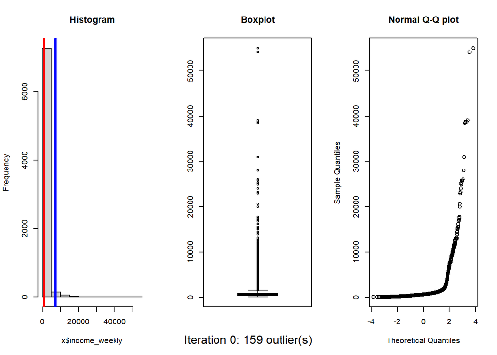

```r
# Take a look at the distribution
par(mfrow = c(1, 3)) # this lets us plot three plots in a row
hist(x$income_weekly, main = "Histogram")
# mark the mean and sds for the histogram
abline(v = mean, col='red', lwd = 3)
abline(v = Tmin, col='blue', lwd = 3)
abline(v = Tmax, col='blue', lwd = 3)
boxplot(x$income_weekly, main = "Boxplot")
qqnorm(x$income_weekly, main = "Normal Q-Q plot")
mtext(paste0("Iteration ", count, ": ", outlier_count, " outlier(s)"), side = 1, line = -2, outer = TRUE)
```

```
Iteration  1 :  148  outliers
```

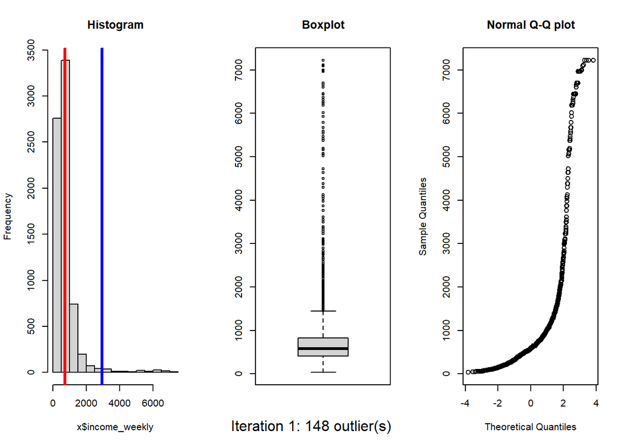

```
Iteration  2 :  160  outliers
```

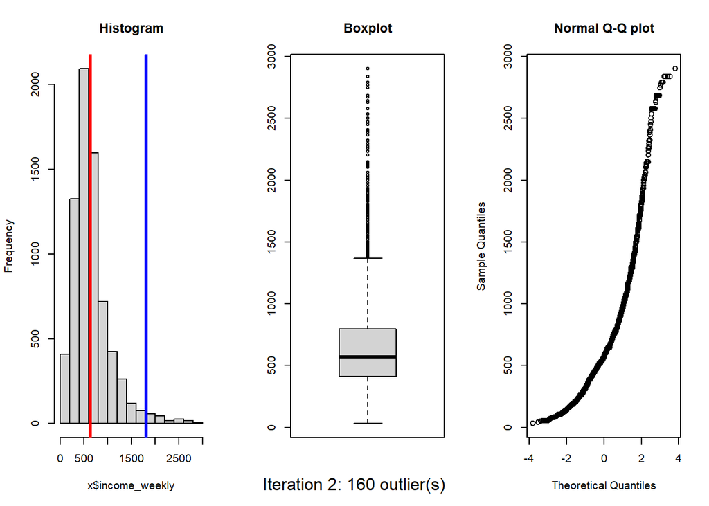

```
Iteration  3 :  94  outliers
```

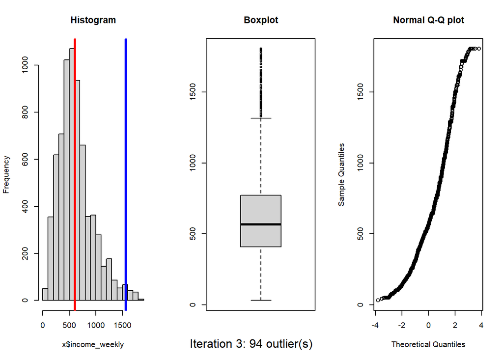

```
Iteration  4 :  64  outliers
```

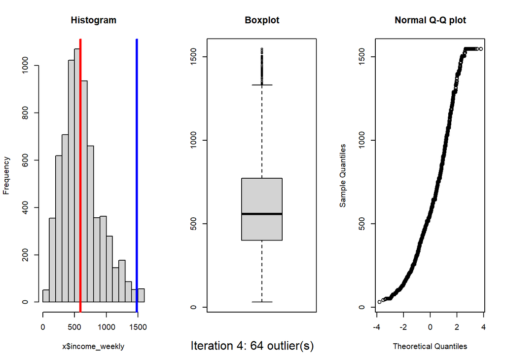

```
Iteration  5 :  18  outliers
```

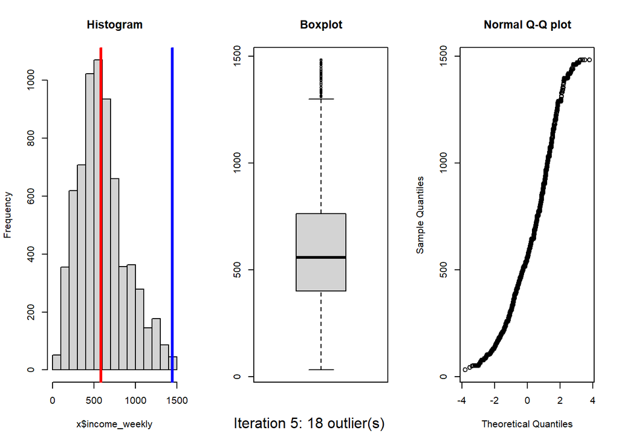

```
Iteration  6 :  6  outliers
```

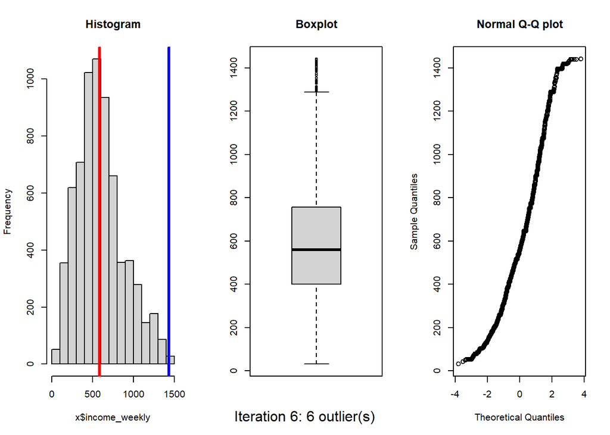

```
Iteration  7 :  1  outliers
```

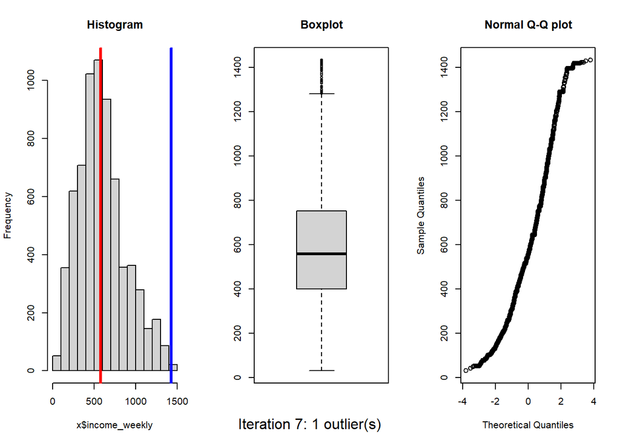

```
Iteration  8 :  0  outliers
```

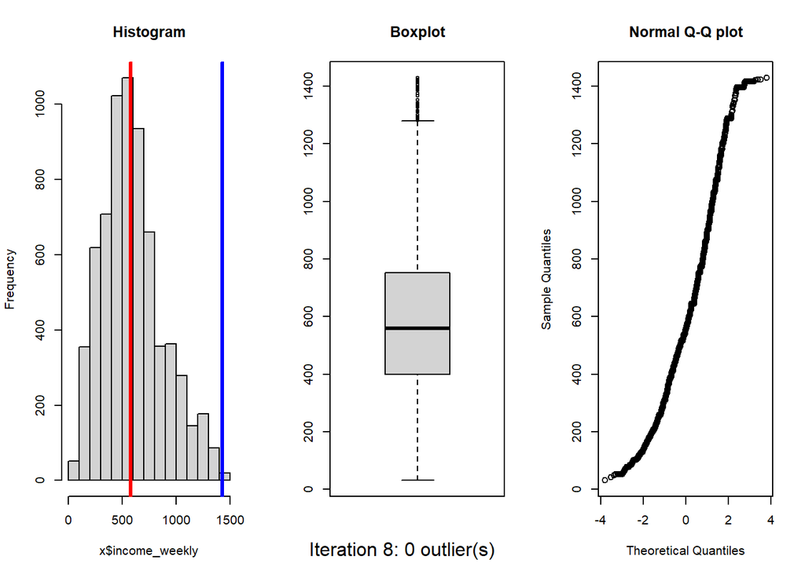

```r
# While there are still outliers detected, remove the outliers and recalculate
# mean, sd, and 3*sd and remove the outliers based on these new figures.
while(length(outliers) != 0){
  count <- count + 1
  x <- x[-outliers,] # remove the outliers identified in the previous iteration

  # recalculate
  mean = Hmisc::wtd.mean(x$income_weekly, weights=x$NatRepemployees, na.rm=T)
  std = sqrt(Hmisc::wtd.var(x$income_weekly,weights=x$NatRepemployees,na.rm = T))
  Tmin = mean - (3 * std)
  Tmax = mean + (3 * std)
  outliers <- which(x$income_weekly < Tmin | x$income_weekly > Tmax)
  outlier_ids <- x$ID[outliers] # get outlier ids
  all_outlier_ids <- append(all_outlier_ids, outlier_ids) # add removed outliers to outlier list
  total_cases_removed <- total_cases_removed + outlier_count # count total

  outlier_count <- length(outliers) # count how many removed this iteration
  cat("Iteration ", count, ": ", outlier_count, " outliers\n")

  # Replot distributions to see how they've changed
  par(mfrow = c(1, 3))
  hist(x$income_weekly, main = "Histogram")
  abline(v = mean, col='red', lwd = 3)
  abline(v = Tmin, col='blue', lwd = 3)
  abline(v = Tmax, col='blue', lwd = 3)
  boxplot(x$income_weekly, main = "Boxplot")
  qqnorm(x$income_weekly, main = "Normal Q-Q plot")
  mtext(paste0("Iteration ", count, ": ", outlier_count, " outlier(s)"), side = 1, line = -2, outer = TRUE)
}
```

```r
cat(total_cases_removed, " cases removed in total, across ", count, " iterations")
```

```
650  cases removed in total, across  8  iterations
```

```r
# Drop the cases identified as outliers from data
data$income_drop[which(data$ID %in% all_outlier_ids)] <- 1
data$income_drop[is.na(data$income_drop)] <- 0 # make NAs 0

# Check this looks right
sum(data$income_drop, na.rm = T) # this should be equal to all_outlier_ids
```

```
[1] 650
```

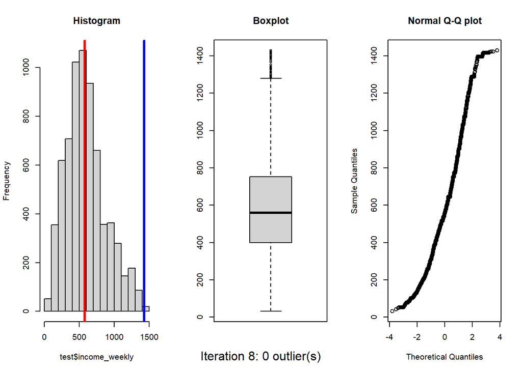

```r
# This should look the same as the last iteration above#
test <- data %>%
  filter(income_drop == 0)

mean = Hmisc::wtd.mean(x$income_weekly, weights=x$NatRepemployees, na.rm=T)
std = sqrt(Hmisc::wtd.var(x$income_weekly,weights=x$NatRepemployees,na.rm = T))
Tmin = mean - (3 * std)
Tmax = mean + (3 * std)

par(mfrow = c(1, 3))
hist(test$income_weekly, main = "Histogram")
abline(v = mean, col='red', lwd = 3)
abline(v = Tmin, col='blue', lwd = 3)
abline(v = Tmax, col='blue', lwd = 3)
boxplot(test$income_weekly, main = "Boxplot")
qqnorm(test$income_weekly, main = "Normal Q-Q plot")
mtext(paste0("Iteration ", count, ": ", outlier_count, " outlier(s)"), side = 1, line = -2, outer = TRUE)
```

As shown above, the process involved 8 iterations, and in total identified 650 observations which should be removed when examining income data (total non-NA income_annual N after removal = 6849). The resulting income distribution is now more sensibly distributed.

### Converting closed responses to continuous

The function below extracts the midpoint of the income brackets, or the value of the “less than” and “over” values.

```r
closed_income <- data %>%
  filter(is.na(INCOME_OPEN_1)) %>%
  select(c(ID, contains("INCOME", ignore.case = F))) %>%
  select(ends_with("labelled"))

convert_to_numeric <- function(data) {
  # Select the closed income columns. We only want the labelled ones.
  matching_columns <- grep("CLOSED", colnames(data), ignore.case = FALSE)
  matching_columns <- matching_columns[grep("labelled", colnames(data)[matching_columns], ignore.case = FALSE)]
  matching_column_names <- colnames(data)[matching_columns]

  #column <- "INCOME_CLOSED_ANNUAL_labelled"
  # Iterate through the closed variables
  # For each one, split its range into two separate values and calculate the midpoint,
  # or for "less than" and "over", just take the value and use that
  for(column in matching_column_names){
    temp_df <- data %>%
      #mutate(copy = INCOME_CLOSED_ANNUAL_labelled) %>% # just for testing
      separate_wider_delim(column, names = c("min_income","max_income"), delim=" up to £", too_few = "align_start")

    temp_df <- temp_df %>%
      mutate(across(c(min_income, max_income), ~gsub("£","",.))) %>% # sub out the £ sign
      # This is for extracting the less than and over values as well subbing out the comma separators
      # regex = 1-3 digits, comma, three digits, decimal point any number of digits
      # In same operation, we also sub out the comma separator
      mutate(
        min_income = gsub(",","", str_extract(min_income, "\\d{1,3}(?:,\\d{3})*(?:\\.\\d+)?"))
      ) %>%
      # sub out the comma separator again (this is just going to be for max_income, but leave in min_income anyway)
      mutate(across(c(min_income, max_income), ~gsub(",","",.))) %>%
      mutate(across(c(min_income, max_income), as.numeric)) %>% # note we lose 'prefer not to say' here
      # Where we have both min and max, calculate the midpoint, otherwise, just keep min
      mutate(midpoint = case_when(!is.na(min_income) & !is.na(max_income) ~ (min_income + max_income) / 2,
                                TRUE ~ min_income)
      )

    # Add the new variable into the data
    data <- data %>%
      mutate(
        midpoint = temp_df$midpoint, .after = column
      )
    # make a sensible colname
    colnames(data)[colnames(data) == "midpoint"] <- paste0(column, "_midpoint")
    }

  return(data)
}

data <- convert_to_numeric(data)
```

Now calculate annual income in the same way as we did for the open questions

```r
data <- data %>%
  # get values of labels
  # mutate_all(haven::as_factor) %>%
  mutate(
    # make all annual incomes. Note this assumes 52 working weeks!
    income_annual_closed = case_when(INCOME_FREQ == 1 ~ INCOME_CLOSED_ANNUAL_labelled_midpoint,
                              INCOME_FREQ == 2 ~ INCOME_CLOSED_MONTHLY_labelled_midpoint*12,
                              INCOME_FREQ == 3 ~ INCOME_CLOSED_WEEKLY_labelled_midpoint*working_weeks,
                              INCOME_FREQ == 4 ~ INCOME_CLOSED_HOURLY_labelled_midpoint*HOURS*working_weeks,
                              TRUE ~ NA),
    income_weekly_closed = case_when(INCOME_FREQ == 1 ~ INCOME_CLOSED_ANNUAL_labelled_midpoint / working_weeks,
                              INCOME_FREQ == 2 ~ (INCOME_CLOSED_MONTHLY_labelled_midpoint*12) / working_weeks,
                              INCOME_FREQ == 3 ~ INCOME_CLOSED_WEEKLY_labelled_midpoint,
                              INCOME_FREQ == 4 ~ INCOME_CLOSED_HOURLY_labelled_midpoint*HOURS,
                              TRUE ~ NA),
    income_hourly_closed = income_weekly_closed / HOURS,
    income_percentile_closed = ntile(income_annual, 100),
    income_weekly_closed_percentile = ntile(income_weekly_closed, 100),
    income_hourly_closed_percentile = ntile(income_hourly_closed, 100),

  )
```

Next, combine the open and closed into a single variable.

```r
data <- data %>%
  mutate(
    income_annual_all = case_when(!is.na(income_annual) ~ income_annual,
                                   !is.na(income_annual_closed) ~ income_annual_closed,
                                   TRUE ~ NA),
    income_weekly_all = case_when(!is.na(income_weekly) ~ income_weekly,
                                   !is.na(income_weekly_closed) ~ income_weekly_closed,
                                   TRUE ~ NA),
    income_hourly_all = case_when(!is.na(income_hourly) ~ income_hourly,
                                   !is.na(income_hourly_closed) ~ income_hourly_closed,
                                   TRUE ~ NA)

  )

# Double check this leads to what we expect
# Yes, this provides the same number of non-na values as calculated above,
# i.e., 1213 total nas: 1212 from closed reponses, 1 from open responses
sum(!is.na(data$income_annual_all))
```

```
[1] 8943
```

```r
sum(is.na(data$income_annual_all))
```

```
[1] 1212
```

```r
sum(!is.na(data$income_weekly_all))
```

```
[1] 8943
```

```r
sum(is.na(data$income_weekly_all))
```

```
[1] 1212
```

```r
sum(!is.na(data$income_hourly_all))
```

```
[1] 8943
```

```r
sum(is.na(data$income_hourly_all))
```

```
[1] 1212
```

Apply the same outliers removal process as done above for the income_all_subset

```r
# annual income all - same result as weekly
x <- data

# calculate the mean and sd, and 3x sd
mean = Hmisc::wtd.mean(x$income_annual_all, weights=x$NatRepemployees, na.rm=T)
std = sqrt(Hmisc::wtd.var(x$income_annual_all,weights=x$NatRepemployees,na.rm = T))
Tmin = mean-(3*std)
Tmax = mean+(3*std)

# identify the first set of outliers
outliers <- which(x$income_annual_all < Tmin | x$income_annual_all > Tmax)
outlier_count <- length(outliers) # count how many removed this iteration
all_outlier_ids <- x$ID[outliers] # list of ids removed (to be removed from data later)

# initialise some variables, i.e. iteration 0
count <- 0 # iteration counter
total_cases_removed <- 0 # total cases removed

cat("Iteration ", count, ": ", outlier_count, " outliers\n")
```

```
Iteration  0 :  173  outliers
```

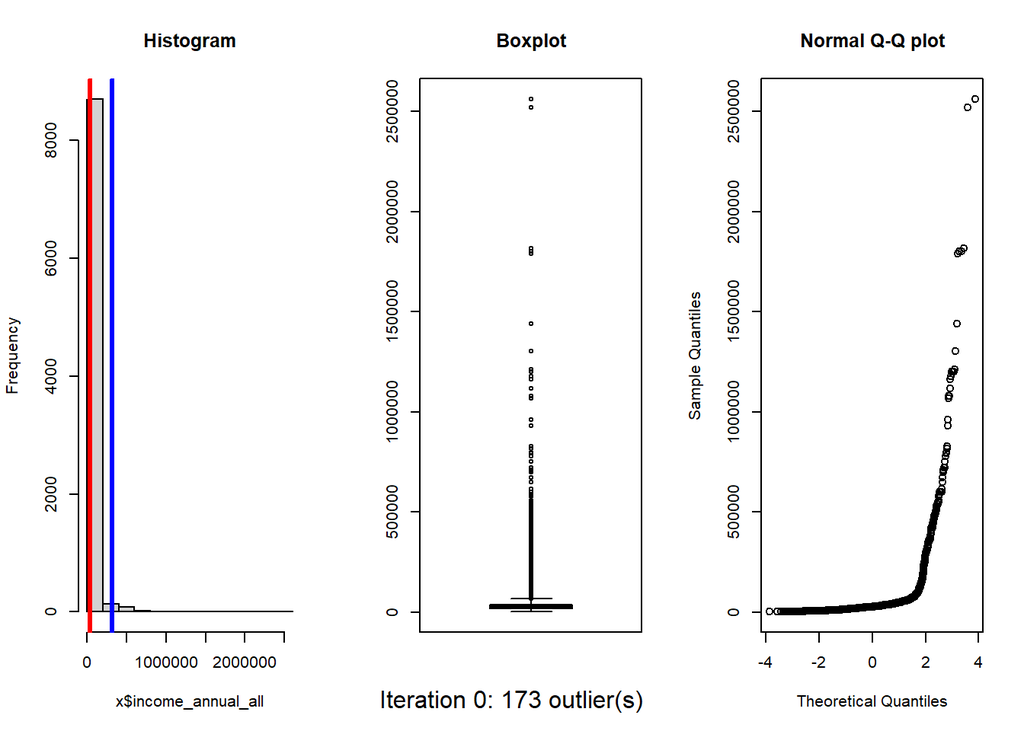

```r
# Take a look at the distribution
par(mfrow = c(1, 3)) # this lets us plot three plots in a row
hist(x$income_annual_all, main = "Histogram")
# mark the mean and sds for the histogram
abline(v = mean, col='red', lwd = 3)
abline(v = Tmin, col='blue', lwd = 3)
abline(v = Tmax, col='blue', lwd = 3)
boxplot(x$income_annual_all, main = "Boxplot")
qqnorm(x$income_annual_all, main = "Normal Q-Q plot")
mtext(paste0("Iteration ", count, ": ", outlier_count, " outlier(s)"), side = 1, line = -2, outer = TRUE)
```

```
Iteration  1 :  155  outliers
```

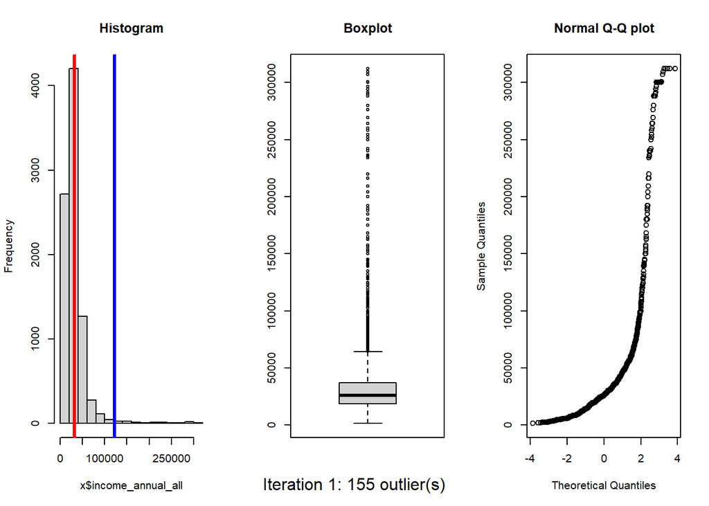

```
Iteration  2 :  180  outliers
```

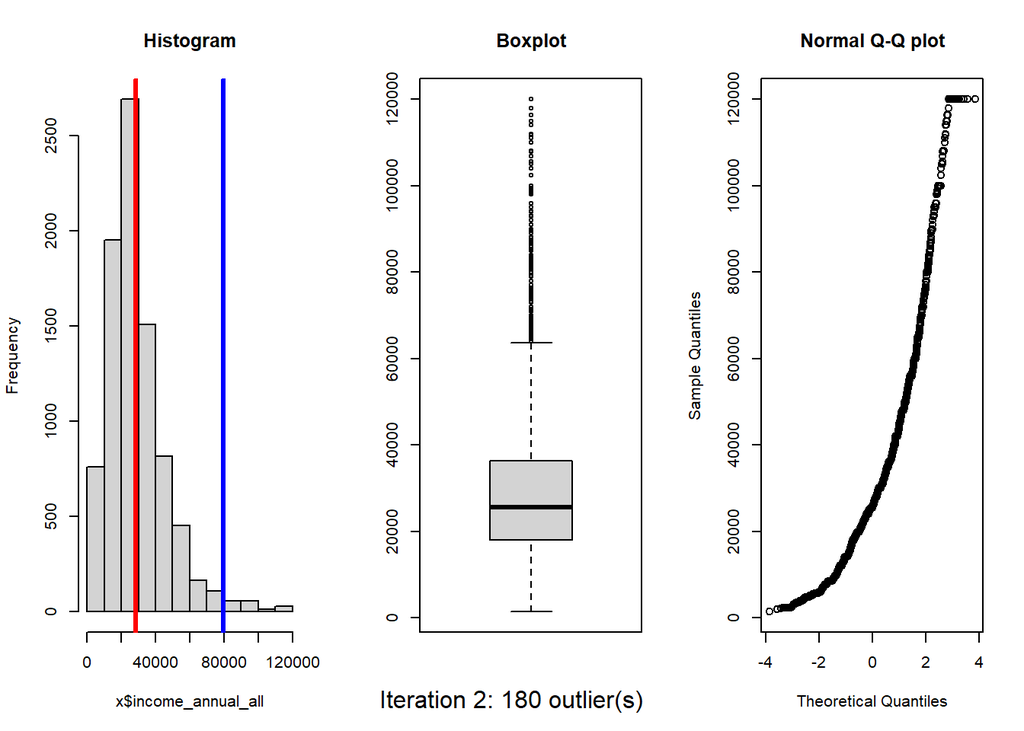

```
Iteration  3 :  88  outliers
```

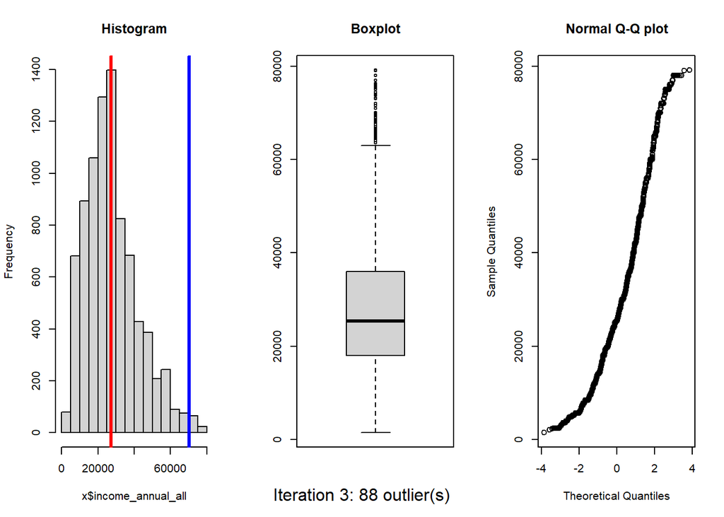

```
Iteration  4 :  46  outliers
```

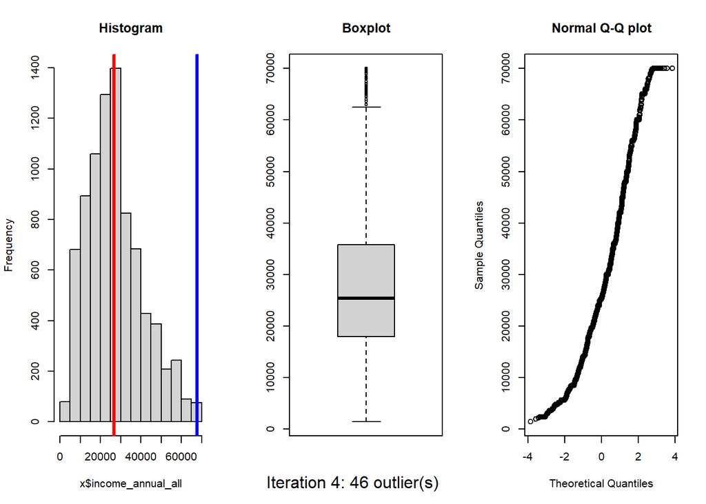

```
Iteration  5 :  9  outliers
```

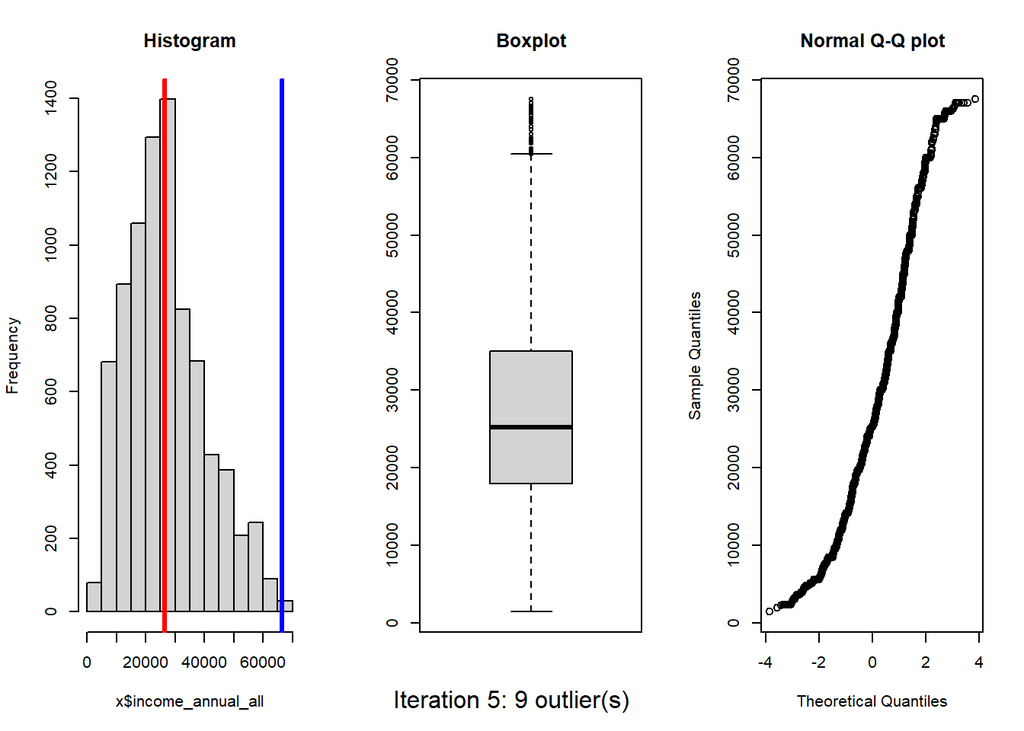

```
Iteration  6 :  1  outliers
```

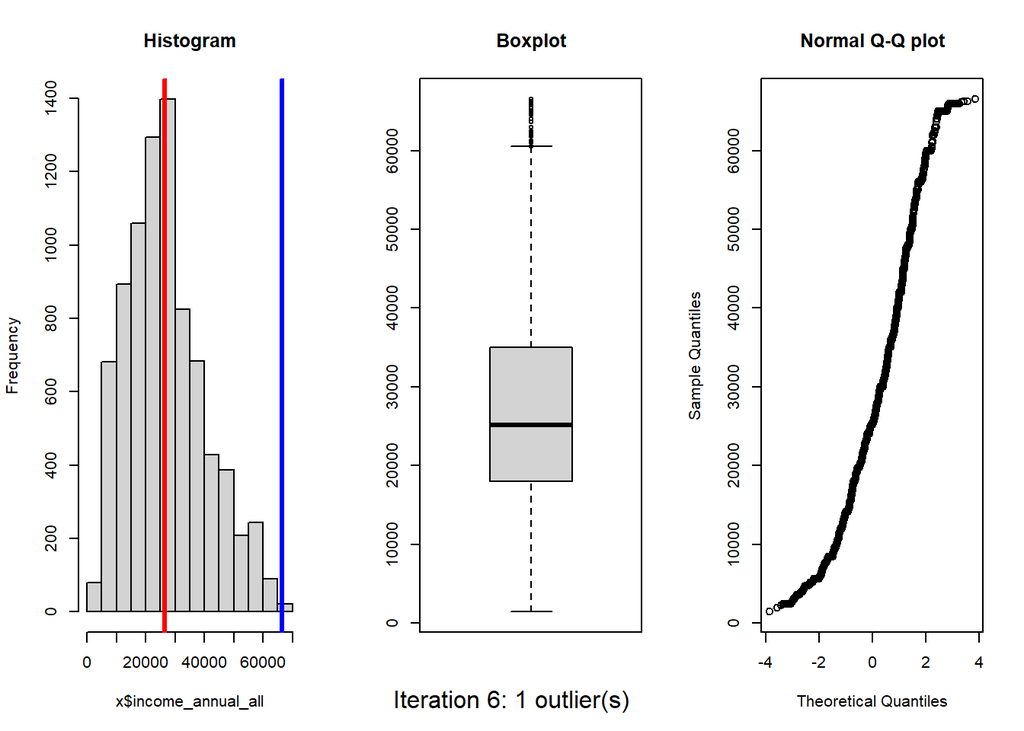

```
Iteration  7 :  0  outliers
```

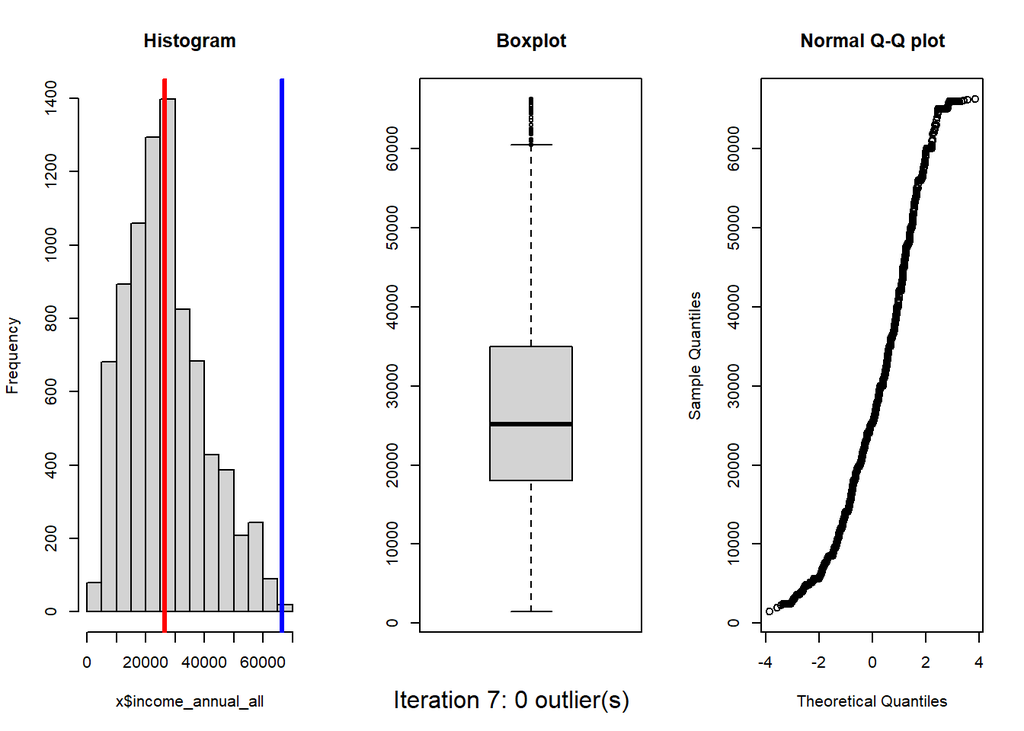

```r
# While there are still outliers detected, remove the outliers and recalculate
# mean, sd, and 3*sd and remove the outliers based on these new figures.
while(length(outliers) != 0){
  count <- count + 1
  x <- x[-outliers,] # remove the outliers identified in the previous iteration

  # recalculate
  mean = Hmisc::wtd.mean(x$income_annual_all, weights=x$NatRepemployees, na.rm=T)
  std = sqrt(Hmisc::wtd.var(x$income_annual_all,weights=x$NatRepemployees,na.rm = T))
  Tmin = mean - (3 * std)
  Tmax = mean + (3 * std)
  outliers <- which(x$income_annual_all < Tmin | x$income_annual_all > Tmax)
  outlier_ids <- x$ID[outliers] # get outlier ids
  all_outlier_ids <- append(all_outlier_ids, outlier_ids) # add removed outliers to outlier list
  total_cases_removed <- total_cases_removed + outlier_count # count total

  outlier_count <- length(outliers) # count how many removed this iteration
  cat("Iteration ", count, ": ", outlier_count, " outliers\n")

  # Replot distributions to see how they've changed
  par(mfrow = c(1, 3))
  hist(x$income_annual_all, main = "Histogram")
  abline(v = mean, col='red', lwd = 3)
  abline(v = Tmin, col='blue', lwd = 3)
  abline(v = Tmax, col='blue', lwd = 3)
  boxplot(x$income_annual_all, main = "Boxplot")
  qqnorm(x$income_annual_all, main = "Normal Q-Q plot")
  mtext(paste0("Iteration ", count, ": ", outlier_count, " outlier(s)"), side = 1, line = -2, outer = TRUE)
}
```

```r
cat(total_cases_removed, " cases removed in total, across ", count, " iterations")
```

```
652  cases removed in total, across  7  iterations
```

```r
# Drop the cases identified as outliers from data
data$income_drop_all[which(data$ID %in% all_outlier_ids)] <- 1
data$income_drop_all[is.na(data$income_drop_all)] <- 0 # make NAs 0

# Check this looks right
sum(data$income_drop_all, na.rm = T) # this should be equal to all_outlier_ids
```

```
[1] 652
```

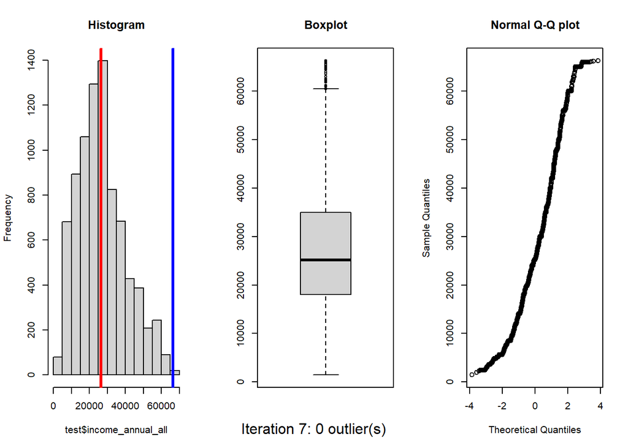

```r
# This should look the same as the last iteration above#
test <- data %>%
  filter(income_drop_all == 0)

mean = Hmisc::wtd.mean(x$income_annual_all, weights=x$NatRepemployees, na.rm=T)
std = sqrt(Hmisc::wtd.var(x$income_annual_all,weights=x$NatRepemployees,na.rm = T))
Tmin = mean - (3 * std)
Tmax = mean + (3 * std)

par(mfrow = c(1, 3))
hist(test$income_annual_all, main = "Histogram")
abline(v = mean, col='red', lwd = 3)
abline(v = Tmin, col='blue', lwd = 3)
abline(v = Tmax, col='blue', lwd = 3)
boxplot(test$income_annual_all, main = "Boxplot")
qqnorm(test$income_annual_all, main = "Normal Q-Q plot")
mtext(paste0("Iteration ", count, ": ", outlier_count, " outlier(s)"), side = 1, line = -2, outer = TRUE)
```

```r
# income weekly all
x <- data

# calculate the mean and sd, and 3x sd
mean = Hmisc::wtd.mean(x$income_weekly_all, weights=x$NatRepemployees, na.rm=T)
std = sqrt(Hmisc::wtd.var(x$income_weekly_all,weights=x$NatRepemployees,na.rm = T))
Tmin = mean-(3*std)
Tmax = mean+(3*std)

# identify the first set of outliers
outliers <- which(x$income_weekly_all < Tmin | x$income_weekly_all > Tmax)
outlier_count <- length(outliers) # count how many removed this iteration
all_outlier_ids <- x$ID[outliers] # list of ids removed (to be removed from data later)

# initialise some variables, i.e. iteration 0
count <- 0 # iteration counter
total_cases_removed <- 0 # total cases removed

cat("Iteration ", count, ": ", outlier_count, " outliers\n")
```

```
Iteration  0 :  173  outliers
```

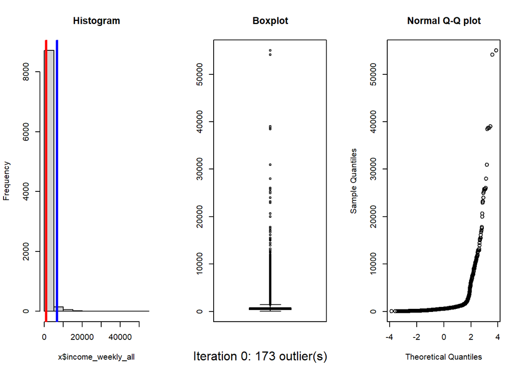

```r
# Take a look at the distribution
par(mfrow = c(1, 3)) # this lets us plot three plots in a row
hist(x$income_weekly_all, main = "Histogram")
# mark the mean and sds for the histogram
abline(v = mean, col='red', lwd = 3)
abline(v = Tmin, col='blue', lwd = 3)
abline(v = Tmax, col='blue', lwd = 3)
boxplot(x$income_weekly_all, main = "Boxplot")
qqnorm(x$income_weekly_all, main = "Normal Q-Q plot")
mtext(paste0("Iteration ", count, ": ", outlier_count, " outlier(s)"), side = 1, line = -2, outer = TRUE)
```

```
Iteration  1 :  155  outliers
```

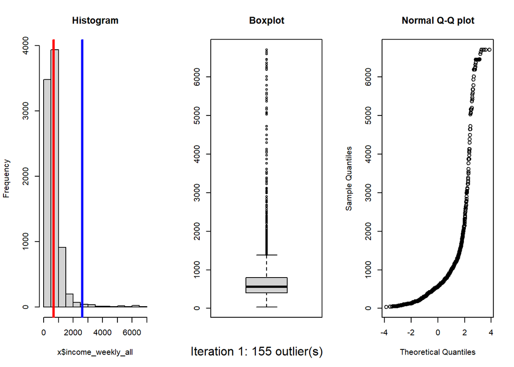

```
Iteration  2 :  180  outliers
```

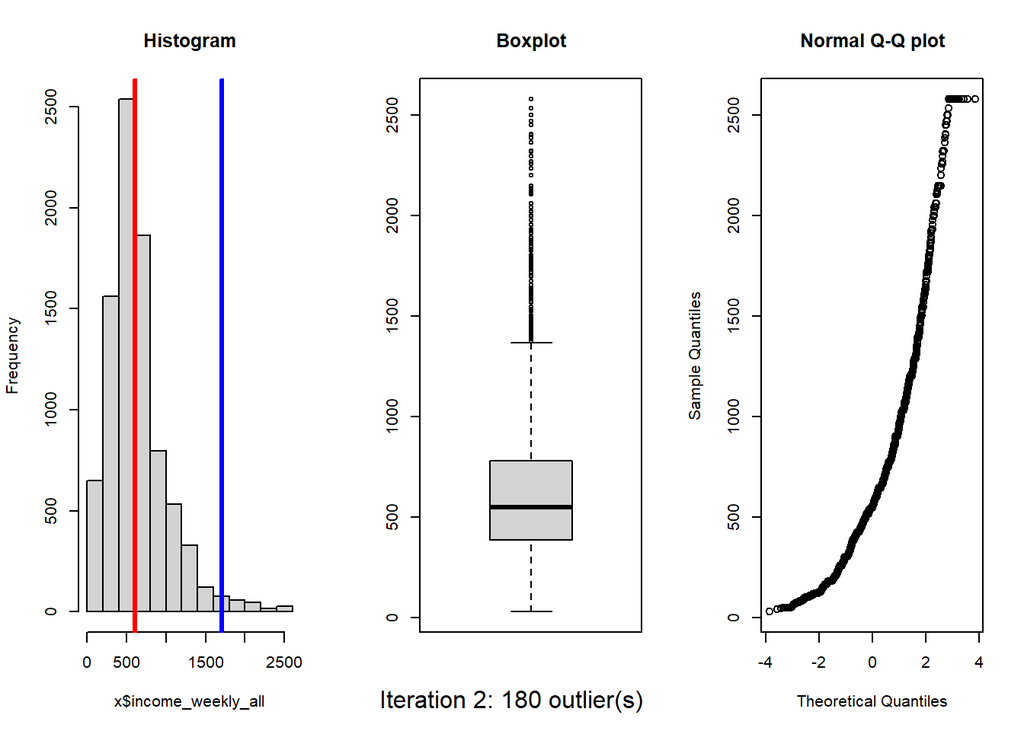

```
Iteration  3 :  88  outliers
```

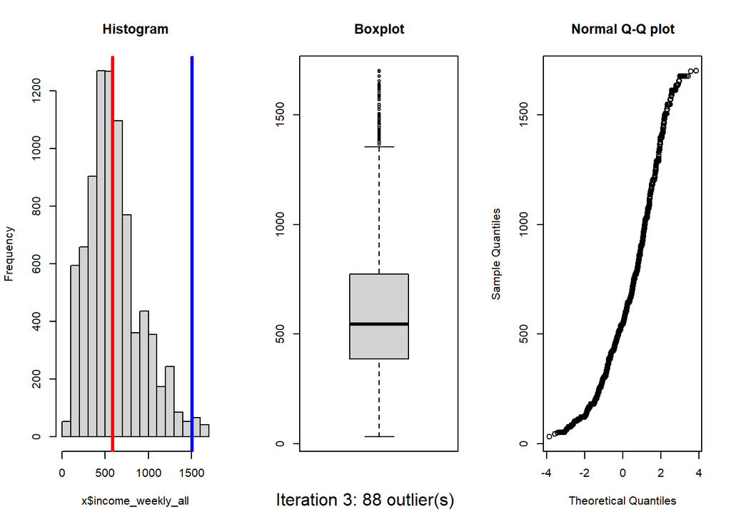

```
Iteration  4 :  46  outliers
```

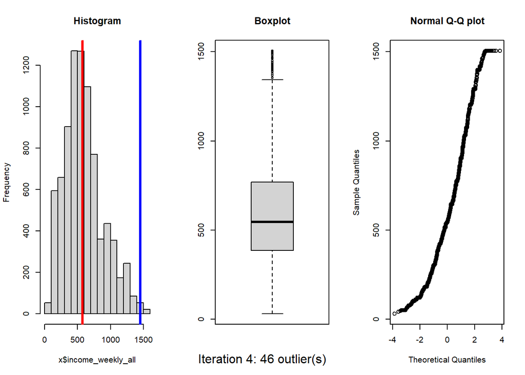

```
Iteration  5 :  9  outliers
```

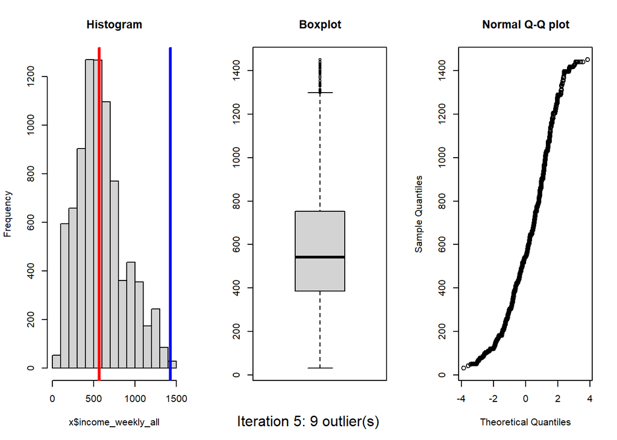

```
Iteration  6 :  1  outliers
```

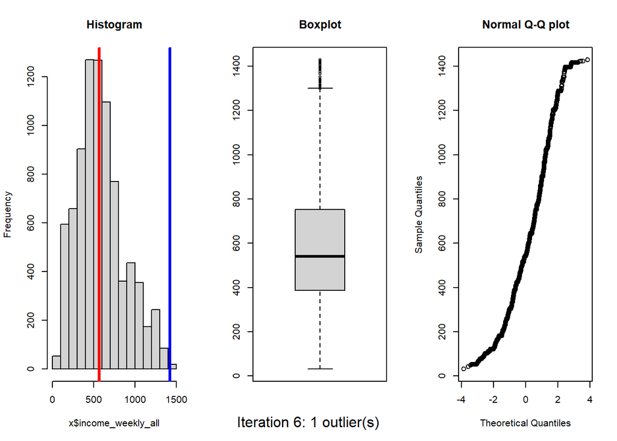

```
Iteration  7 :  0  outliers
```

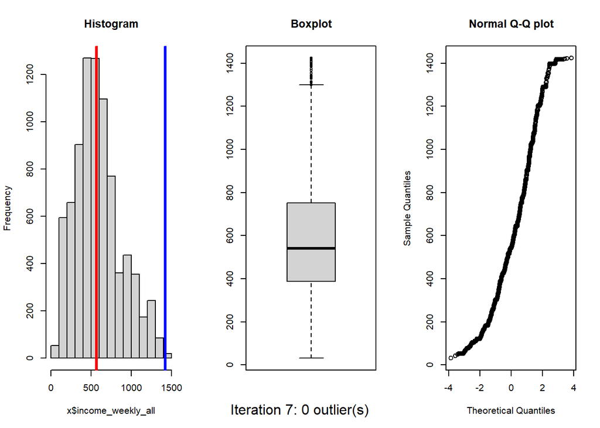

```r
# While there are still outliers detected, remove the outliers and recalculate
# mean, sd, and 3*sd and remove the outliers based on these new figures.
while(length(outliers) != 0){
  count <- count + 1
  x <- x[-outliers,] # remove the outliers identified in the previous iteration

  # recalculate
  mean = Hmisc::wtd.mean(x$income_weekly_all, weights=x$NatRepemployees, na.rm=T)
  std = sqrt(Hmisc::wtd.var(x$income_weekly_all,weights=x$NatRepemployees,na.rm = T))
  Tmin = mean - (3 * std)
  Tmax = mean + (3 * std)
  outliers <- which(x$income_weekly_all < Tmin | x$income_weekly_all > Tmax)
  outlier_ids <- x$ID[outliers] # get outlier ids
  all_outlier_ids <- append(all_outlier_ids, outlier_ids) # add removed outliers to outlier list
  total_cases_removed <- total_cases_removed + outlier_count # count total

  outlier_count <- length(outliers) # count how many removed this iteration
  cat("Iteration ", count, ": ", outlier_count, " outliers\n")

  # Replot distributions to see how they've changed
  par(mfrow = c(1, 3))
  hist(x$income_weekly_all, main = "Histogram")
  abline(v = mean, col='red', lwd = 3)
  abline(v = Tmin, col='blue', lwd = 3)
  abline(v = Tmax, col='blue', lwd = 3)
  boxplot(x$income_weekly_all, main = "Boxplot")
  qqnorm(x$income_weekly_all, main = "Normal Q-Q plot")
  mtext(paste0("Iteration ", count, ": ", outlier_count, " outlier(s)"), side = 1, line = -2, outer = TRUE)
}
```

```r
cat(total_cases_removed, " cases removed in total, across ", count, " iterations")
```

```
652  cases removed in total, across  7  iterations
```

```r
# Drop the cases identified as outliers from data
data$income_drop_all[which(data$ID %in% all_outlier_ids)] <- 1
data$income_drop_all[is.na(data$income_drop_all)] <- 0 # make NAs 0

# Check this looks right
sum(data$income_drop_all, na.rm = T) # this should be equal to all_outlier_ids
```

```
[1] 652
```

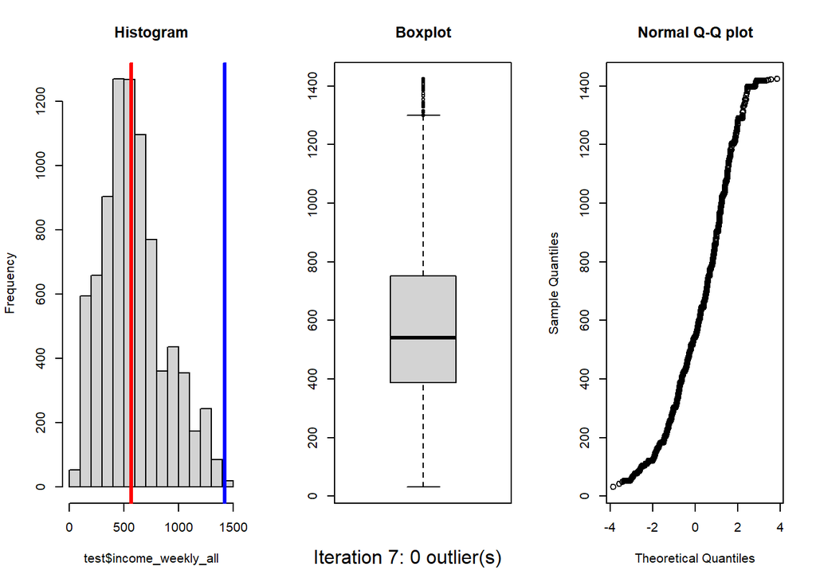

```r
# This should look the same as the last iteration above#
test <- data %>%
  filter(income_drop_all == 0)

mean = Hmisc::wtd.mean(x$income_weekly_all, weights=x$NatRepemployees, na.rm=T)
std = sqrt(Hmisc::wtd.var(x$income_weekly_all,weights=x$NatRepemployees,na.rm = T))
Tmin = mean - (3 * std)
Tmax = mean + (3 * std)

par(mfrow = c(1, 3))
hist(test$income_weekly_all, main = "Histogram")
abline(v = mean, col='red', lwd = 3)
abline(v = Tmin, col='blue', lwd = 3)
abline(v = Tmax, col='blue', lwd = 3)
boxplot(test$income_weekly_all, main = "Boxplot")
qqnorm(test$income_weekly_all, main = "Normal Q-Q plot")
mtext(paste0("Iteration ", count, ": ", outlier_count, " outlier(s)"), side = 1, line = -2, outer = TRUE)
```

### Applying income brackets - revisons on 30/09/2024

After further discussion and consultation with JRF analysts, who felt the 80% threshold was high, we have reverted to use 2/3 ASHE regional weekly pay as the threshold. This is also consistent with what JRF have done in the past and what the OECD uses (see https://data.oecd.org/earnwage/wage-levels.htm).

```r
# get the ashe data
# from https://www.ons.gov.uk/employmentandlabourmarket/peopleinwork/earningsandworkinghours/datasets/earningsandhoursworkedukregionbyagegroup
url <- 'https://www.ons.gov.uk/file?uri=/employmentandlabourmarket/peopleinwork/earningsandworkinghours/datasets/earningsandhoursworkedukregionbyagegroup/2023provisional/ashetableregionbyage2023provisional.zip'

filename <- basename(url) # this takes the filename from the url
filepath <- paste0("../data/", filename)
output_dir <- substr(filepath,start = 1, stop=nchar(filepath) - 4)

# check if the file exists. if it doesn't, download and unzip
if(!file.exists(filepath)){
  cat("Downloading data\n")
  download.file(url, destfile = filepath, mode = "wb")
  unzip(filepath,exdir=output_dir)
} else{
  cat("Data already in directory. Loading it.\n")
}
```

```
Data already in directory. Loading it.
```

```r
# Specify the directory
# Use list.files to get all CSV files in the directory
files <- list.files(path = output_dir, pattern = '* Weekly pay - Gross 2023.xls$', full.names = TRUE)

ashe_data <- readxl::read_excel(files[1], sheet = 'All', skip = 4) %>%
  filter(!is.na(Code)) %>%
  #select(-c(last_col(offset=2):last_col(), contains('change'))) %>% # if we want some other variables
  janitor::clean_names() %>%
  rename(
    #jobs_thousands = thousand,
    Region = description,
    Region_median_income = median
  ) %>%
  select(Region, Region_median_income) %>% # if we just want the median
  # rename problematic regions
  mutate(
    Region = case_when(Region == "East" ~ "East of England",
                       Region == "Yorkshire and The Humber" ~ "Yorkshire and the Humber",
                       TRUE ~ Region),
    Region_median_income = as.numeric(Region_median_income)
    )
```

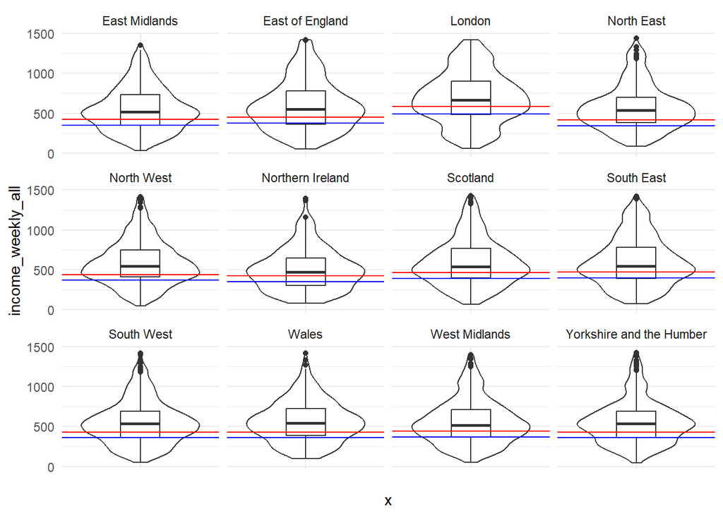

```r
# join to data
data <- data %>%
  left_join(., ashe_data, by = "Region")

# calcualte 4/5 thresholds
data <- data %>%
  mutate(
    Region_four_fifths =  Region_median_income * .8,
    Region_two_thirds = Region_median_income * (2/3),
    UK_median = ashe_data %>% filter(Region == "United Kingdom") %>% pull(Region_median_income),
    UK_four_fifths = UK_median * 0.8
  )


# stats by region
income_statistics_regional <- data %>%
  filter(income_drop == 0 & !is.na(income_weekly_all)) %>%
  group_by(Region) %>%
  summarise(
    mean = weighted.mean(income_weekly_all, w = NatRepemployees, na.rm = T),
    median = wtd.quantile(income_weekly_all, w = NatRepemployees, probs = c(.5), na.rm = T),
    min = wtd.quantile(income_weekly_all, w = NatRepemployees, probs = c(0), na.rm = T),
    max = wtd.quantile(income_weekly_all, w = NatRepemployees, probs = c(1), na.rm = T),
    stdev = sqrt(wtd.var(income_weekly_all, w = NatRepemployees, na.rm = T)),
    n = n()
  )

par(mar = c(2, 2, 2, 2))
# plot the distribution of income
# blue lines are regional values, red lines are UK values
# lighter lines are the actual medians, darker lines are 4/5 medians
# data %>%
#   filter(income_drop == 0 & !is.na(income_weekly_all)) %>%
#   ggplot(., aes(x="",y=income_weekly_all)) +
#   facet_wrap(~Region) +
#   geom_violin() +
#   geom_boxplot(width = 0.3) +
#   geom_hline(aes(yintercept = UK_median), colour = "red", alpha=0.25) +
#   geom_hline(aes(yintercept = UK_four_fifths), colour = "red") +
#   geom_hline(aes(yintercept = Region_median_income), colour = "blue", alpha = 0.25) +
#   geom_hline(aes(yintercept = Region_four_fifths), colour = "blue") +
#   theme_minimal()

# let's take a look at two-thrids too
# here blue lines are 2/3, red lines are 4/5
data %>%
  filter(income_drop == 0 & !is.na(income_weekly_all)) %>%
  ggplot(., aes(x="",y=income_weekly_all)) +
  facet_wrap(~Region) +
  geom_violin() +
  geom_boxplot(width = 0.3) +
  geom_hline(aes(yintercept = Region_four_fifths), colour = "red") +
  geom_hline(aes(yintercept = Region_two_thirds), colour = "blue") +
  theme_minimal()
```

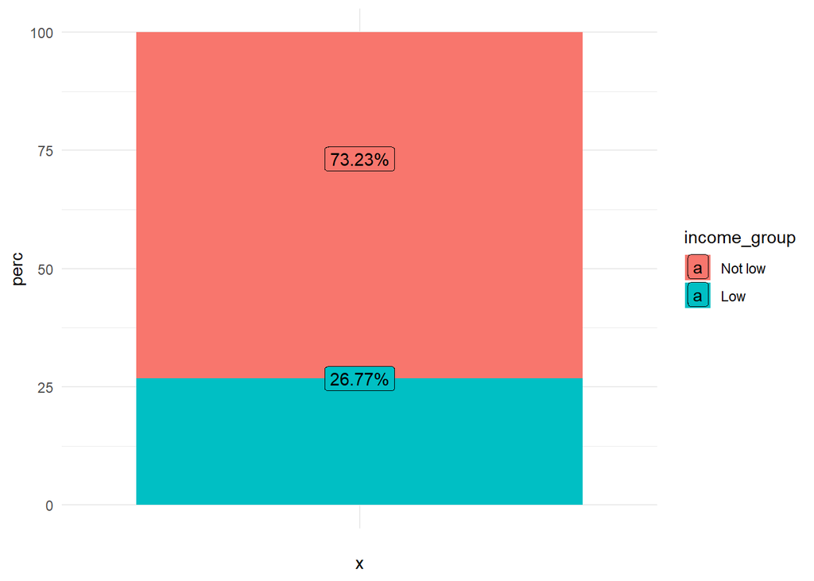

```r
# use 2/3 becuase that's what OECD use and what JRF have used in past
# https://data.oecd.org/earnwage/wage-levels.htm

# create the grouping variable based on Region_two_thirds
# low pay is less than or equal to 2/3 regional median earnigns
data <- data %>%
  mutate(
    income_group = case_when(income_weekly_all <= Region_two_thirds  ~ "Low",
                             income_weekly_all > Region_two_thirds ~ "Not low",
                             TRUE ~ NA),
    income_group = factor(income_group, levels = c("Not low","Low"), exclude=NA)
  ) %>%
  ungroup()


# visualise it to check
# 26.77% of people are low paid
data %>%
  filter(income_drop == 0 & !is.na(income_weekly_all)) %>%
  dplyr::group_by(income_group) %>%
  dplyr::summarise(
    n = sum(NatRepemployees)
  ) %>%
  mutate(
    perc = 100 * (n / sum(n))
  ) %>%
  ggplot(aes("", perc, fill=income_group)) +
  geom_col() +
  theme_minimal() +
  #theme(plot.margin = unit(c(0,4,0,4), "inches")) +
  geom_label(aes(label=paste0(round(perc,2),"%")))
```

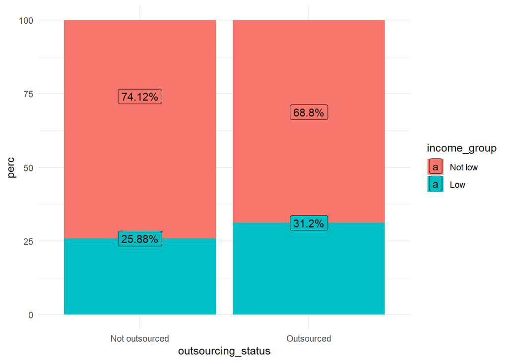

```r
## comparing outsoruced to not outsourced
## 25.88% NO are low paid, 31.2% O are low paid
data %>%
  filter(income_drop == 0 & !is.na(income_weekly_all)) %>%
  dplyr::group_by(outsourcing_status, income_group) %>%
  dplyr::summarise(
    n = sum(NatRepemployees)
  ) %>%
  mutate(
    perc = 100 * (n / sum(n))
  ) %>%
  ggplot(aes(outsourcing_status, perc, fill=income_group)) +
  geom_col() +
  theme_minimal() +
  #theme(plot.margin = unit(c(0,4,0,4), "inches")) +
  geom_label(aes(label=paste0(round(perc,2),"%")))
```

```r
# one last check to see people have been categorised correctly
# test <- data %>%
#   filter(income_drop==0) %>% # why do we still get nas for annual income?
#   select(Annual_Income, Region_four_fifths, income_group) %>%
#   mutate(
#     test = case_when(Annual_Income < Region_four_fifths ~ "Low",
#                      Annual_Income >= Region_four_fifths ~ "Not low",
#                      TRUE ~ NA)
#   )
# # check that they're the same - value should be 0
# sum(test$income_group != test$test, na.rm=T)
```

```r
# test significance
mod <- glm(income_group ~ outsourcing_status, data, family="binomial", weights = NatRepemployees)
summary(mod)
```

```
Call:
glm(formula = income_group ~ outsourcing_status, family = "binomial",
    data = data, weights = NatRepemployees)

Coefficients:
                             Estimate Std. Error z value             Pr(>|z|)
(Intercept)                  -1.13900    0.02717 -41.918 < 0.0000000000000002
outsourcing_statusOutsourced  0.21801    0.06292   3.465              0.00053

(Intercept)                  ***
outsourcing_statusOutsourced ***
---
Signif. codes:  0 '***' 0.001 '**' 0.01 '*' 0.05 '.' 0.1 ' ' 1

(Dispersion parameter for binomial family taken to be 1)

    Null deviance: 10002.1  on 8942  degrees of freedom
Residual deviance:  9990.4  on 8941  degrees of freedom
  (1212 observations deleted due to missingness)
AIC: 10890

Number of Fisher Scoring iterations: 4
```

```r
test <- summary(mod)

or <- exp(mod[["coefficients"]][["outsourcing_statusOutsourced"]])
p <- test[["coefficients"]][2,4]
```

The difference is confirmed statistically. An outsourced person is 1.24 times more likely to be in the low income group compared to a non-outsourced person (*p* = 0.001). In the full analysis we can control for other factors when testing this relationship (e.g., age, gender, etc).

### Improving N for income

When reporting income, respondents could choose whether to report income using an open text method or a bracket method. All income-based work in this report so far has used only the open text methods. We may be interested to combine data from the CLOSED questions with the OPEN ones, although there is not a clear method for doing so. Possible options are:

1. Make all numeric. This would involve taking the midpoint of the bracket for CLOSED responses and using that as a numeric value. I think this is very questionable because it will impact the distribution and effectively make it meaningless.
2. Make all brackets. This would involve categorising the numeric income data into the same brackets that are present in the CLOSED method. This would maximise our coverage - as all incomes can be sensibly harmonised - but it would mean we don’t have a distribution to work with, which limits how we apply thresholds to responses and limits the resolution with which we can look at the income data.
3. Continue to keep them separate. This involves doing what we can separately with the two types of reporting method. Advantage is we maximise coverage. Disadvantages are that it will double the work and muddy the picture (as we have to consider income in two different ways).

```r
income_subset <- data %>%
  select(INCOME_FREQ, contains("INCOME_OPEN"), income_annual, contains("INCOME_CLOSED_")) %>%
  mutate(
    INCOME_FREQ = haven::as_factor(INCOME_FREQ)
  )

# Check whether any of the income closed variables has non-missing on same rows as income open (derived). There are none.
vars <- colnames(select(income_subset, contains("INCOME_CLOSED")))
for(i in vars){
  cat(paste0(i,": ",sum(!is.na(income_subset$income_annual) & !is.na(income_subset[i]))), "\n")
}
```

```
INCOME_CLOSED_ANNUAL: 0
INCOME_CLOSED_ANNUAL_labelled: 0
INCOME_CLOSED_ANNUAL_labelled_midpoint: 0
INCOME_CLOSED_MONTHLY: 0
INCOME_CLOSED_MONTHLY_labelled: 0
INCOME_CLOSED_MONTHLY_labelled_midpoint: 0
INCOME_CLOSED_WEEKLY: 0
INCOME_CLOSED_WEEKLY_labelled: 0
INCOME_CLOSED_WEEKLY_labelled_midpoint: 0
INCOME_CLOSED_HOURLY: 0
INCOME_CLOSED_HOURLY_labelled: 0
INCOME_CLOSED_HOURLY_labelled_midpoint: 0
```

```r
# Skim indicates completion of closed weekly/hourly is really low, but monthyl/annual is a bit better. We might want to try and combine somehow. Think about code to exract hte numbers from brackets, then take the midpoint of the two numbers. Extract after '£', to ' '. But into two separate elements to start
skim(income_subset)
```

Data summary

| Name | income_subset |
| --- | --- |
| Number of rows | 10155 |
| Number of columns | 16 |
| _______________________ |  |
| Column type frequency: |  |
| factor | 5 |
| numeric | 11 |
| ________________________ |  |
| Group variables | None |

**Variable type: factor**

| skim_variable | n_missing | complete_rate | ordered | n_unique | top_counts |
| --- | --- | --- | --- | --- | --- |
| INCOME_FREQ | 0 | 1.00 | FALSE | 4 | Ann: 4515, Mon: 4215, Wee: 764, Hou: 661 |
| INCOME_CLOSED_ANNUAL_labelled | 9315 | 0.08 | FALSE | 12 | Pre: 380, £22: 74, £28: 60, £16: 58 |
| INCOME_CLOSED_MONTHLY_labelled | 8748 | 0.14 | FALSE | 12 | Pre: 635, £1,: 157, £94: 125, £1,: 120 |
| INCOME_CLOSED_WEEKLY_labelled | 9884 | 0.03 | FALSE | 12 | Pre: 118, £33: 32, £11: 29, £22: 24 |
| INCOME_CLOSED_HOURLY_labelled | 10018 | 0.01 | FALSE | 11 | Pre: 78, £10: 31, £12: 9, £14: 6 |

**Variable type: numeric**

| skim_variable | n_missing | complete_rate | mean | sd | p0 | p25 | p50 | p75 | p100 | hist |
| --- | --- | --- | --- | --- | --- | --- | --- | --- | --- | --- |
| INCOME_OPEN_1 | 2656 | 0.74 | 21132.05 | 29878.94 | 6.00 | 1516.5 | 13500.0 | 33000.0 | 750000 | ▇▁▁▁▁ |
| INCOME_OPEN_2 | 7500 | 0.26 | 0.00 | 0.00 | 0.00 | 0.0 | 0.0 | 0.0 | 0 | ▁▁▇▁▁ |
| income_annual | 2656 | 0.74 | 46884.73 | 104977.77 | 1440.00 | 19200.0 | 27588.0 | 40000.0 | 2559857 | ▇▁▁▁▁ |
| INCOME_CLOSED_ANNUAL | 9315 | 0.08 | 8.96 | 3.38 | 1.00 | 6.0 | 11.0 | 12.0 | 12 | ▁▂▂▂▇ |
| INCOME_CLOSED_ANNUAL_labelled_midpoint | 9695 | 0.05 | 33070.85 | 14140.52 | 5600.00 | 25200.5 | 30800.5 | 47600.5 | 56000 | ▃▇▃▆▇ |
| INCOME_CLOSED_MONTHLY | 8748 | 0.14 | 7.86 | 4.12 | 1.00 | 4.0 | 8.0 | 12.0 | 12 | ▃▃▂▁▇ |
| INCOME_CLOSED_MONTHLY_labelled_midpoint | 9383 | 0.08 | 1873.08 | 1043.83 | 470.00 | 1175.5 | 1645.5 | 2585.5 | 4700 | ▇▇▂▂▂ |
| INCOME_CLOSED_WEEKLY | 9884 | 0.03 | 7.49 | 4.29 | 1.00 | 4.0 | 7.0 | 12.0 | 12 | ▅▃▂▁▇ |
| INCOME_CLOSED_WEEKLY_labelled_midpoint | 10002 | 0.02 | 390.74 | 228.44 | 110.00 | 165.0 | 385.5 | 495.5 | 1100 | ▇▆▂▂▁ |
| INCOME_CLOSED_HOURLY | 10018 | 0.01 | 9.11 | 4.73 | 1.00 | 3.0 | 13.0 | 13.0 | 13 | ▃▂▁▁▇ |
| INCOME_CLOSED_HOURLY_labelled_midpoint | 10096 | 0.01 | 13.13 | 4.60 | 8.91 | 11.0 | 11.0 | 13.0 | 30 | ▇▂▁▁▁ |

Feedback from 8 May was to incorporate the closed responses with the open responses. This has been done in the section above Converting closed responses to continuous.

## Sector

Create a variable for shortened sector names to make them nicer to read.

```r
data <- data %>%
  mutate(
    SectorName_short = SectorName_labelled
  ) %>%
  # make the sector names more readable
  separate_wider_delim(SectorName_short, names = c("SectorName_short", "SectorName_short_detail"), delim=";",
                       too_few = "align_start") %>%
  mutate(
    SectorName_short = factor(stringr::str_to_sentence(SectorName_short)),
    SectorName_short_detail = factor(stringr::str_to_sentence(SectorName_short_detail))
  )
```

## Region

Make region a factor and make the reference London.

```r
data <- data %>%
  mutate(
    Region = forcats::fct_relevel(factor(Region), "London")
  )
```

# Some final cleaning that was at beginning of analysis script

```r
# Make our disaggregated ethnicity groups identical to the original census groups
# as per request in JRF - Outsourced workers - To dos

data$Ethnicity_collapsed_disaggregated <- data$Ethnicity_labelled

data <- data %>%
  mutate(
    Ethnicity_collapsed = case_when(
      # Grouping White ethnicities
      Ethnicity %in% c(1) ~ "White British", # Just white british as reference
      Ethnicity %in% c(2, 3, 4, 5) ~ "White other", # Gyspy, Irish traveller, Roma, Irish and White other grouped together
      # Grouping Asian ethnicities
      Ethnicity %in% c(10,11,12,13,14) ~ "Asian/Asian British",
      # Grouping Black ethnicities
      Ethnicity %in% c(15,16,17) ~ "Black/African/Caribbean/Black British",
      # Grouping Mixed ethnicities
      Ethnicity %in% c(6,7,8,9) ~ "Mixed/Multiple ethnic group",
      # Grouping Other ethnicities
      Ethnicity %in% c(18) ~ "Arab/British Arab",
      # Handling missing or ambiguous categories
      Ethnicity %in% c(19)  ~ "Other ethnic group",
      #prefer not to say
      Ethnicity %in% c(20,21) ~ "Prefer not to say",
      # Default case for any unmatched entries
      TRUE ~ "Prefer not to say"
    )
  )

#make white the reference category
data$Ethnicity_collapsed <- relevel(factor(data$Ethnicity_collapsed), ref = "White British")

data <- data %>%
  mutate(
    Has_Degree = factor(Has_Degree, levels = c("No", "Yes", "Don't know"))
  )

# make binary born uk var
categories <- as.vector(unique(data$BORNUK_labelled))
non_categories <- categories[!(categories %in% "I was born in the UK")]

# Will throw NA warning. I think this OK but investigate how to avoid the problem
data <- data %>%
  mutate(
    BORNUK_binary = forcats::fct_collapse(BORNUK_labelled,
                                      "Born in UK" = "I was born in the UK",
                                      "Not born in UK" = non_categories)
  )

# make binary ethnicity var
ethnicities <- as.vector(unique(data$Ethnicity_collapsed))
non_white_ethnicities <- ethnicities[!(ethnicities %in% "White British")]

# Will throw NA warning. I think this OK but investigate how to avoid the problem
data <- data %>%
  mutate(
    Ethnicity_binary = forcats::fct_collapse(Ethnicity_collapsed,
                                      "White British" = c("White British"),
                                      "Non-White British" = non_white_ethnicities)
  )
```

## Save

```r
check <- readline("Save data? (y/n)")
```

```
Save data? (y/n)
```

```r
if(check=="y"){
  saveRDS(data, file = paste0("../Data/", format(Sys.Date(), "%Y-%m-%d"), " - Cleaned_Data.rds"))
# haven::write_sav(as.data.frame(data), path = paste0("../Data/", format(Sys.Date(), "%Y-%m-%d"), " - Cleaned_Data.sav"))
  write_csv(data, file = paste0("../Data/", format(Sys.Date(), "%Y-%m-%d"), " - Cleaned_Data.csv"))
  print("File saved")
} else{
  print("File not saved")
}
```

```
[1] "File not saved"
```